# Final Project: Language Models With Different Tokenisations

In this project we compared several small GPT-style language models trained on the same long-form book corpus. We started from dataset preparation and tokenisation, then studied compact hyperparameter variations, selected final configurations, trained the final models for longer runs, and evaluated the saved best-validation checkpoints.

We intentionally kept the final comparison focused on the compact parameter studies and the longer 100,000-iteration final runs. The final model choice was based on validation behaviour, perplexity, generalisation gap, model size, and generated samples.

## 1. Project Goal

The goal is to compare small GPT-style language models trained on the same book corpus but using different tokenisation strategies:

- character-level tokens
- syllable-level tokens
- GPT-2/tiktoken word-subword tokens
- compact local-word tokens

The final comparison focuses on validation loss, validation perplexity, generalisation gap, generated samples, and the practical tradeoff between vocabulary size, model size, and text quality.

## Colab Setup: Mount Drive And Extract Computed Models

We stored the trained model repository in Google Drive as `MyDrive/LM_Project/final_model_repository.zip`. This cell mounts Drive, extracts the archive, and sets `MODEL_REPOSITORY_DIR` for the final evaluation.

```python
# Mount Drive and extract the already-trained model repository and parameter-study CSVs.

from pathlib import Path
import zipfile
from google.colab import drive

drive.mount('/content/drive')

project_drive_dir = Path('/content/drive/MyDrive/LM_Project')
model_zip_path = project_drive_dir / 'final_model_repository.zip'
parameter_zip_path = project_drive_dir / 'parameter_study_artifacts.zip'

MODEL_REPOSITORY_DIR = Path('/content/final_model_repository')
PARAMETER_STUDY_DIR = Path('/content/parameter_study_artifacts')

if not (MODEL_REPOSITORY_DIR / 'manifest.json').exists():
    MODEL_REPOSITORY_DIR.mkdir(parents=True, exist_ok=True)
    with zipfile.ZipFile(model_zip_path, 'r') as zf:
        zf.extractall(MODEL_REPOSITORY_DIR)

if not (PARAMETER_STUDY_DIR / 'pg19_parameter_study_manifest.csv').exists():
    PARAMETER_STUDY_DIR.mkdir(parents=True, exist_ok=True)
    with zipfile.ZipFile(parameter_zip_path, 'r') as zf:
        zf.extractall(PARAMETER_STUDY_DIR)

print('Using model repository:', MODEL_REPOSITORY_DIR)
print('Using parameter-study artifacts:', PARAMETER_STUDY_DIR)
print('Best checkpoints:')
for path in sorted((MODEL_REPOSITORY_DIR / 'checkpoints').glob('*_best_gpt.pt')):
    print(' -', path.name)
```

```
Using model repository: /content/final_model_repository
Using parameter-study artifacts: /content/parameter_study_artifacts
Best checkpoints:
 - characters_best_gpt.pt
 - local_words_best_gpt.pt
 - syllables_best_gpt.pt
 - word_subwords_best_gpt.pt
```

## 2. Dataset And Preprocessing

We loaded a PG-19 sample, inspected basic corpus statistics, removed clearly non-narrative titles using the available title metadata, and built the cleaned corpora used by the tokenisers.

### Libraries Installation And Imports

We use PyTorch for the GPT model, NLTK for syllable tokenization, and `tiktoken` for word/subword tokenization.

```python
# Import the main libraries and prepare the working environment.

from pathlib import Path
from itertools import product
import datetime
import gc
import json
import math
import random
import re
import time
import warnings

import numpy as np
import pandas as pd
import matplotlib.pyplot as plt
import seaborn as sns
import requests
from tqdm.auto import tqdm
from datasets import load_dataset

import torch
import torch.nn as nn
from torch.nn import functional as F

from nltk.tokenize import SyllableTokenizer
import tiktoken

warnings.filterwarnings("ignore")

RANDOM_SEED = 42
random.seed(RANDOM_SEED)
np.random.seed(RANDOM_SEED)
torch.manual_seed(RANDOM_SEED)

sns.set_theme(style="whitegrid", context="notebook")
plt.rcParams["figure.figsize"] = (10, 5)


device = "cuda" if torch.cuda.is_available() else "cpu"
print("Device:", device)

PROJECT_DIR = Path.cwd()
CACHE_DIR = PROJECT_DIR / "data" / "cache"
CACHE_DIR.mkdir(parents=True, exist_ok=True)
```

```
Device: cuda
```

```python
# Set up output folders for Colab or local execution.
# In Colab we save intermediate artifacts in Drive; locally we save them next to the project.
import os

try:
    import google.colab
    IN_COLAB = True
except ImportError:
    IN_COLAB = False

if IN_COLAB:
    from google.colab import drive
    drive.mount('/content/drive')
    DRIVE_DIR = Path('/content/drive/MyDrive/LM_Project')
    DRIVE_DIR.mkdir(parents=True, exist_ok=True)
    MODEL_DIR = DRIVE_DIR / 'models'
    ARTIFACT_DIR = DRIVE_DIR / 'artifacts'
    print(f'Colab detected — project files will persist to: {DRIVE_DIR}')
else:
    MODEL_DIR = PROJECT_DIR / 'models'
    ARTIFACT_DIR = PROJECT_DIR / 'artifacts'
    print(f'Local environment — project files will be saved to: {PROJECT_DIR}')

MODEL_DIR.mkdir(parents=True, exist_ok=True)
ARTIFACT_DIR.mkdir(parents=True, exist_ok=True)
```

```
Colab detected — project files will persist to: /content/drive/MyDrive/LM_Project
```

### Dataset Overview

We used a PG-19 / Project Gutenberg-style dataset: a language-modeling benchmark made from books published before 1919. PG-19 was useful here because it contains real, long-form prose rather than short fragmented texts. Earlier experiments with poetry and song-lyrics data produced weaker semantic continuity, so we moved to books for the final project.

This helped the models produce more coherent samples than the shorter fragmented-text experiments. The tradeoff was size: PG-19 is much larger, so we streamed a configurable number of books and cached the local sample.

The first corpus kept light book metadata such as title and publication date. The compact local-word model used the text-only corpus so generation stayed in prose form instead of drifting into metadata fields.

## 2.1 Dataset Loading

PG-19 is large, so we did not download the whole dataset by default. Instead, we streamed a configurable number of books, kept the first `N_BOOKS` records from the training split, and cached them locally as JSONL.

We used a higher `N_BOOKS` value for the final run and lower values during debugging or CPU tests. When one Hugging Face mirror was unavailable, the loader tried the next candidate.

```python
DATASET_CANDIDATES = [
    "emozilla/pg19",
    "Tanushreeeeee/pg19",
]
DATASET_NAME = None
N_BOOKS = 400
FORCE_RELOAD = False
SAMPLE_CACHE_PATH = CACHE_DIR / f"pg19_book_sample_{N_BOOKS}.jsonl"


def normalize_record(record):
    """
    take one raw dataset record and return a clean, standardized dictionary
    """
    return {
        "short_book_title": str(record.get("short_book_title") or record.get("title") or "Untitled"),
        "publication_date": record.get("publication_date", None),
        "url": str(record.get("url") or ""),
        "text": str(record.get("text") or ""),
    }


if SAMPLE_CACHE_PATH.exists() and not FORCE_RELOAD:
    raw_df = pd.read_json(SAMPLE_CACHE_PATH, lines=True)
    print(f"Loaded {len(raw_df):,} books from cache: {SAMPLE_CACHE_PATH}")
else:
    records = []
    load_error_messages = []
    for candidate_name in DATASET_CANDIDATES:
        try:
            # load the training split using Hugging Face load_dataset
            streamed_dataset = load_dataset(candidate_name, split="train", streaming=True)
            DATASET_NAME = candidate_name
            for record in streamed_dataset:
                normalized = normalize_record(record)
                if normalized["text"].strip():
                    records.append(normalized)
                # stop once we have N_BOOKS (120)
                if len(records) >= N_BOOKS:
                    break
            if records:
                break
        except Exception as exc:
            load_error_messages.append(f"{candidate_name}: {exc}")

    if not records:
        raise RuntimeError("Could not load a PG-19 dataset candidate. Errors:\n" + "\n".join(load_error_messages))

    # Convert the list of book dictionaries into a pandas DataFrame
    raw_df = pd.DataFrame(records)

    # Save the sampled books to the cache file
    # orient = "records" : each row becomes a JSON object
    # lines  = True      : saves as JSONL, one record per line
    # force_ascii = False: keeps non ASCII char instead of escaping them
    raw_df.to_json(SAMPLE_CACHE_PATH, orient="records", lines=True, force_ascii=False)
    print(f"Loaded and cached {len(raw_df):,} books from {DATASET_NAME} at {SAMPLE_CACHE_PATH}")

raw_df.head()
```

```
Loaded and cached 400 books from emozilla/pg19 at /content/data/cache/pg19_book_sample_400.jsonl
```

|  | short_book_title | publication_date | url | text |
| --- | --- | --- | --- | --- |
| 0 | The Bible Both Testaments King James Version | 1611 | http://www.gutenberg.org/ebooks/10 | \n\n\n\n\n\n\n\n\n\n\n\n\n\nThe Old Testament ... |
| 1 | The Complete Works of William Shakespeare | 1623 | http://www.gutenberg.org/ebooks/100 | \n\n\n\nProduced by World Library, Inc., from ... |
| 2 | The House on the Borderland by William Hope Ho... | 1908 | http://www.gutenberg.org/ebooks/10002 | \n\n\n\nProduced by Suzanne Shell, Sjaani and ... |
| 3 | My First Years As A Frenchwoman 1876-1879 by M... | 1914 | http://www.gutenberg.org/ebooks/10003 | \n\n\n\nThis file was produced from images gen... |
| 4 | The Warriors by Anna Robertson Brown Lindsay | 1902 | http://www.gutenberg.org/ebooks/10004 | \n\n\n\nProduced by Charles Aldarondo, Charlie... |

```python
# Sanity check
print("Shape:", raw_df.shape)
print("Columns:", raw_df.columns.tolist())
# check for missing values
raw_df[["short_book_title", "publication_date", "url", "text"]].isna().sum()
```

```
Shape: (400, 4)
Columns: ['short_book_title', 'publication_date', 'url', 'text']
```

|  | 0 |
| --- | --- |
| short_book_title | 0 |
| publication_date | 0 |
| url | 0 |
| text | 0 |

**dtype:** int64

```python
# length statistics for each book
raw_df["raw_char_count"] = raw_df["text"].fillna("").astype(str).str.len()
raw_df["raw_word_count"] = raw_df["text"].fillna("").astype(str).str.split().str.len()
raw_df["raw_paragraph_count"] = raw_df["text"].fillna("").astype(str).apply(lambda value: len([p for p in value.split("\n\n") if p.strip()]))

raw_df[["raw_char_count", "raw_word_count", "raw_paragraph_count"]].describe().T
```

|  | count | mean | std | min | 25% | 50% | 75% | max |
| --- | --- | --- | --- | --- | --- | --- | --- | --- |
| raw_char_count | 400.0 | 400783.4275 | 452871.713952 | 2171.0 | 148133.50 | 290214.0 | 509488.00 | 5443801.0 |
| raw_word_count | 400.0 | 69958.0525 | 78997.849883 | 364.0 | 27039.25 | 51875.0 | 90122.25 | 900741.0 |
| raw_paragraph_count | 400.0 | 1309.6150 | 1766.702601 | 48.0 | 389.75 | 851.0 | 1752.75 | 24610.0 |

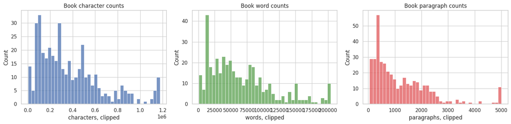

```python
fig, axes = plt.subplots(1, 3, figsize=(16, 4))

# book char counts
sns.histplot(raw_df["raw_char_count"].clip(upper=raw_df["raw_char_count"].quantile(0.98)), bins=40, ax=axes[0])
axes[0].set_title("Book character counts")
axes[0].set_xlabel("characters, clipped")

# book word counts
sns.histplot(raw_df["raw_word_count"].clip(upper=raw_df["raw_word_count"].quantile(0.98)), bins=40, ax=axes[1], color="#59A14F")
axes[1].set_title("Book word counts")
axes[1].set_xlabel("words, clipped")

# book paragraph counts
sns.histplot(raw_df["raw_paragraph_count"].clip(upper=raw_df["raw_paragraph_count"].quantile(0.98)), bins=40, ax=axes[2], color="#E15759")
axes[2].set_title("Book paragraph counts")
axes[2].set_xlabel("paragraphs, clipped")

plt.tight_layout()
plt.show()
```

### Title-Based Corpus Cleanup

The PG-19 records we used do not include a clean `genre` column, so we could not filter the dataset with a real genre variable. In the first runs we used the fuller corpus, but the generated samples were noticeably worse: the models often mixed narrative prose with biblical language, recipe-like instructions, magazine fragments, poetry, and non-fiction headings.

Because of that, we used an LLM as a support tool to help draft a small title-based exclusion list. The LLM was not used to label every book; it helped us turn the obvious problematic title patterns into keyword groups, such as religious texts, poetry/drama, magazines, history/politics, and manuals. We then applied those terms to the available `short_book_title` metadata.

This removed 88 clearly non-narrative books from the final sample. The goal was not to make a perfect genre classifier, but to make the training corpus more consistent for prose generation.

```python
# Use the title as a proxy because the dataset does not provide a clean genre column.
# After poor early results on the full corpus, we used an LLM as support
# to turn the most obvious problematic cases into keyword groups.
# The filter does not classify every book: it only removes clearly non-narrative titles.

religious_terms = [
    'bible', 'testament', 'sermon', 'epistle', 'gospel',
    'faith of the millions', 'healing of nations',
]

poetry_and_drama_terms = [
    'adonais', 'divine comedy', 'inferno', 'purgator',
    'poetical works', 'fairies and fusilier', 'vigil of venus',
    'eulogies', 'the trojan women',
]

periodical_and_anthology_terms = [
    'punchinello', 'atlantic monthly', 'mirror of literature',
    'strand magazine', 'great english short-story writers',
    'stories of great american',
]

history_politics_and_culture_terms = [
    'chinese literature', 'moorish literature', 'oriental literature',
    'great events', 'famous historian', 'chronicles of canada',
    'american political ideas', 'plain words from america',
    'mobilizing woman', 'life of hon. william',
]

manuals_and_misc_terms = [
    'household management', 'english housewifery', 'foreign dishes',
    'baseball guide', 'rhetoric and poetry', 'discourses',
    'folk-lore of plants', 'complete works of william shakespeare',
    'works of aphra behn', 'works of charles and mary lamb',
    'towards the goal', 'thaumaturgia', 'klondyke nuggets',
    'the warriors by anna', 'home-life of the lancashire',
]

excluded_title_terms = (
    religious_terms
    + poetry_and_drama_terms
    + periodical_and_anthology_terms
    + history_politics_and_culture_terms
    + manuals_and_misc_terms
)

title_filter_pattern = re.compile(
    '|'.join(re.escape(term) for term in excluded_title_terms),
    re.I,
)

mask = ~raw_df['short_book_title'].str.contains(title_filter_pattern, na=False)
removed_df = raw_df[~mask]
raw_df = raw_df[mask].reset_index(drop=True)

print(f'Title cleanup: kept {len(raw_df)} books, removed {len(removed_df)}')
print('\nRemoved titles:')
for title in sorted(removed_df['short_book_title'].tolist()):
    print(f'  - {title}')
```

```
Title cleanup: kept 312 books, removed 88

Removed titles:
  - 365 Foreign Dishes by Unknown Author
  - Adonais by Shelley
  - All Saints' Day and Other Sermons by Charles Kingsley
  - American Political Ideas Viewed From The Standpoint
  - Bible Stories and Religious Classics by Philip P. Wells
  - Chinese Literature by Anonymous
  - Chronicles of Canada Volume 12 of 32 The Father of British Canada:
  - Discourses by Thomas H. Huxley
  - Divine Comedy Complete by Dante Alighieri
  - Divine Comedy Complete by Dante Alighieri
  - Divine Comedy Hell by Dante Alighieri
  - Divine Comedy Inferno by Dante Alighieri
  - Divine Comedy Paradise by Dante Alighieri
  - Divine Comedy Paradise by Dante Alighieri
  - Divine Comedy Purgatory by Dante Alighieri
  - Divine Comedy Purgatory by Dante Alighieri
  - Edgar Allan Poe's Complete Poetical Works
  - English Housewifery Exemplified by Elizabeth Moxon
  - Fairies and Fusiliers by Robert Graves
  - Great Events by Famous Historians Vol. 17 by Charles Francis Horne
  - Great Events by Famous Historians Volume 21 by Various
  - Home-Life of the Lancashire Factory Folk during the Cotton Famine
  - Klondyke Nuggets by Joseph Ladue
  - Memoir and Diary of John Yeardley Minister of the Gospel
  - Mobilizing Woman-Power by Harriot Stanton Blatch
  - Moorish Literature by Anonymous
  - Oriental Literature by Anonymous
  - Plain Words From America by Douglas W. Johnson
  - Poetical Works of Joseph Addison John Gay and William Sommerville
  - Punchinello Vol. 1 No. 18 July 30 1870 by Various
  - Punchinello Vol. 1 No. 19 August 6 1870 by Various
  - Punchinello Vol. 1 No. 21 August 20 1870 by Various
  - Punchinello Vol. 1 No. 22 August 27 1870 by Various
  - Punchinello Vol. 1 No. 23 September 3 1870 by Various
  - Punchinello Vol. 1 No. 24 September 10 1870 by Various
  - Punchinello Vol. 1 No. 25 September 17 1870 by Various
  - Punchinello Vol. 1 No. 26 September 24 1870 by Various
```

[output cut: 36 more lines]

```
  - The Mirror of Literature Amusement and Instruction
  - The Mirror of Literature Amusement and Instruction
  - The Mirror of Literature Amusement and Instruction
  - The Mirror of Literature Amusement and Instruction by Various
  - The Mirror of Literature Amusement and Instruction by Various
  - The Poetical Works of Edmund Spenser Volume 5
  - The Poetical Works of William Wordsworth Volume 1
  - The Strand Magazine Vol. 7 No. 37 Jan 1894 by Various
  - The Trojan Women by Euripides
  - The Vigil of Venus and Other Poems by Q
  - The Warriors by Anna Robertson Brown Lindsay
  - The Works of Aphra Behn Vol. 3
  - The Works of Charles and Mary Lamb Vol. 2: Elia by Charles Lamb
  - The Works of Charles and Mary Lamb Vol. 3 Books for Children
  - Towards The Goal by Mrs. Humphry Ward
```

## 2.2 Corpus Construction

Each book is first represented as:

```
Title: ...
Publication date: ...
URL: ...

book text...
```

Books are then joined with the ASCII unit separator . This gives the language model an explicit end-of-book symbol during training and generation.

We also keep a second list called `book_texts`, which contains only the book body. The compact local word model uses that cleaner version so generations stay in prose form instead of drifting into metadata fields.

```python
# We clean the raw text fields and build two corpora:
# - books: each book with metadata plus body text
# - book_texts: only the book body text

def normalize_text_field(value, fallback=""):
    value = str(value) if value is not None else fallback

    # \u00a0 is a special kind of space that appears in web text taht can behave weirdly
    value = value.replace("\u00a0", " ")

    # replace repeated spaces or tabs with a single space
    value = re.sub(r"[ \t]+", " ", value)

    # limit very long runs of newlines, replacing them with exactly 3 newlines
    value = re.sub(r"\n{4,}", "\n\n\n", value)

    # remove whitespaces from the beginning and end
    return value.strip()

books = []
book_texts = []

for _, row in raw_df.iterrows():
    title = normalize_text_field(row.get("short_book_title", "Untitled"), "Untitled")
    publication_date = normalize_text_field(row.get("publication_date", "Unknown"), "Unknown")
    url = normalize_text_field(row.get("url", ""), "")
    body = normalize_text_field(row.get("text", ""), "")

    # only keep books with non-empty text
    if body:
        # create a metadata header
        metadata = f"Title: {title}\nPublication date: {publication_date}\nURL: {url}".strip()

        # full version: matadata + body
        books.append(f"{metadata}\n\n{body}")

        # just body text
        book_texts.append(body)

print(f"Usable books in training corpus: {len(books):,}")
print(f"Usable books in text-only corpus: {len(book_texts):,}")
print(books[0][:1200])
```

```
Usable books in training corpus: 312
Usable books in text-only corpus: 312
Title: The House on the Borderland by William Hope Hodgson
Publication date: 1908
URL: http://www.gutenberg.org/ebooks/10002

Produced by Suzanne Shell, Sjaani and PG Distributed Proofreaders


THE HOUSE ON THE BORDERLAND

William Hope Hodgson


_From the Manuscript discovered in 1877 by Messrs. Tonnison and
Berreggnog in the Ruins that lie to the South of the Village of
Kraighten, in the West of Ireland. Set out here, with Notes_.


TO MY FATHER
_(Whose feet tread the lost aeons)_

Open the door,
 And listen!
Only the wind's muffled roar,
 And the glisten
Of tears 'round the moon.
 And, in fancy, the tread
Of vanishing shoon--
 Out in the night with the Dead.

"Hush! And hark
 To the sorrowful cry
Of the wind in the dark.
 Hush and hark, without murmur or sigh,
 To shoon that tread the lost aeons:
 To the sound that bids you to die.
Hush and hark! Hush and Hark!"
 _Shoon of the Dead_


AUTHOR'S INTRODUCTION TO THE MANUSCRIPT

Many are the hours in which I have pondered upon the story that is set
forth in the following pages. I trust that my instincts are not awry
when they prompt me to leave the account, in simplicity, as it was
handed to me.

And the MS. itself--You must picture
```

## 3. Tokenisation

Within the project we compare several ways of representing the same text. We created character, syllable, GPT-2 subword, and compact local-word encodings so the final models could be compared under different vocabulary granularities.

### Tokenisation Details

We study three representations of the same text:

1. characters
2. syllables
3. words/subwords

The same GPT architecture can be trained on each representation by changing the vocabulary and encoded token stream.

## 3.1 Characters

The character-processing model sees every character as a token. This creates a small vocabulary and usually produces text with plausible spelling, punctuation, line breaks, and repeated book-like structure, although it may need many steps to learn long-range coherence.

```python
valid_chars = '\x1F\t\n\r !"#$%&\'()*+,-./0123456789:;<=>?@ABCDEFGHIJKLMNOPQRSTUVWXYZ[\\]^_`abcdefghijklmnopqrstuvwxyz{|}~æë–—‘’“”'
# \x1F == <EOS>

def remove_invalid_chars_regex(text):
    return ''.join(re.findall(f"[{re.escape(valid_chars)}]+", text))

# This joins all books into one long text string, using \x1F between books
text = remove_invalid_chars_regex('\x1F'.join(books))
text_only = remove_invalid_chars_regex('\x1F'.join(book_texts))

unique_chars = sorted(list(set(text)))
print(' '.join(ch if ch != '\x1F' else '<EOS>' for ch in unique_chars))
print(f"\nCharacter vocabulary size: {len(unique_chars)}")
```

```
 <EOS>   ! " # $ % & ' ( ) * + , - . / 0 1 2 3 4 5 6 7 8 9 : ; < = > ? @ A B C D E F G H I J K L M N O P Q R S T U V W X Y Z [ \ ] ^ _ ` a b c d e f g h i j k l m n o p q r s t u v w x y z { | } ~ æ ë – — ‘ ’ “ ”

Character vocabulary size: 105
```

```python
# Character-level Tokenizer

# 1. we map chars to integer IDs
char_to_int = {ch: i for i, ch in enumerate(unique_chars)}
#    and integers IDs back to chars -> reverse mapping
#                                      (used to turn generated model output back into readable text)
int_to_char = {i: ch for i, ch in enumerate(unique_chars)}

def encode_chars(s):
    """
    This function converts a string into a list of integers IDs
    """
    return [char_to_int[c] for c in s]


def decode_chars(ids):
    """
    This converts integer IDs back into text
    """
    return ''.join(
        '\n---------------------------\n\n'
        if int_to_char[int(i)] == '\x1F'
        else int_to_char[int(i)]
        for i in ids
    )


# data_c encodes the full char corpus into integer IDs and stores it as a PyTorch tensor
# dtype=torch.long : this is important because embedding layers in PyTorch expect integer token IDs
#                    as long tensors
data_c = torch.tensor(encode_chars(text), dtype=torch.long)

# vocab_size_c stores the char vocabulary size
# the GPT model needs this number because the token embedding table has one row per vocabulary item
vocab_size_c = len(unique_chars)

print("Character data tensor:", data_c.shape)
```

```
Character data tensor: torch.Size([118198328])
```

## 3.2 Syllables

The syllable-processing model works at a middle granularity: larger than characters, smaller than words.

We use NLTK's sonority-based syllable tokenizer, lowercase text, and split digits to reduce vocabulary size.

```python
def syllabify(text_value):
    """
    This function takes a text string and returns a list of tokens (syllables)
    """
    # [\w\x1F]+   : matches sequences of words (\w: letters, digits, underscore) + \x1F
    # [^\w\s\x1F] : matches punctuation or symbols: chars that are not words(\w), withespaces (\s) or \x1F
    # \s          : matches whitespaces
    # ----------->  we preserve words, punctuation and whitespace as separate tokens
    tokens = re.findall(r'[\w\x1F]+|[^\w\s\x1F]|\s', text_value)

    syllables = []
    ssp = SyllableTokenizer()

    for token in tokens:

        if re.match(r'\w+', token):
            # if the token is a word-like token, split it into syllables and add them to the list
            syllables.extend(ssp.tokenize(token))
        else:
            # if the token is punctuation, whitespace or something else, keep it as-is
            syllables.append(token)
    return syllables


def syllabify_lowercase_and_digits(text_value):
    """
    This funzion lowercases text and handles digits specially
    """
    tokens = re.findall(r'\d+|[a-z]+|\d+[a-z]+|[^\w\s]|[\s]|\x1F', text_value.lower())
    syllables = []
    ssp = SyllableTokenizer()

    for token in tokens:
        if token == '\x1F':
            # keep the book separator unchanged
            syllables.append(token)

        elif token.isdigit():
            # if the token is a number we split it into individual digits
            syllables.extend(list(token))

        elif re.match(r'[a-z]+', token):
            # if the token is a word, split it into syllables
            syllables.extend(ssp.tokenize(token))

        elif re.match(r'\d+[a-z]+', token):
            # if it is mixed (e.g. 12th) we split it into number and suffix (-> e.g. "12", "th")
            number, suffix = re.match(r'(\d+)([a-z]+)', token).groups()

            # the number becomes individual digits
            syllables.extend(list(number))

            # the suffix gets syllabified
            syllables.extend(ssp.tokenize(suffix))
        else:
            # punctutation and whitespares are kept
            syllables.append(token)
    return syllables


# Here we compute two syllable vocabularies:
# 1. raw/original-case syllable vocabulary
unique_syllables = sorted(set(syllabify(text)))
# 2. lowercase + digit-normalized syllable vocabl
unique_lc_syllables = sorted(set(syllabify_lowercase_and_digits(text)))

print("Raw syllable vocabulary size:", len(unique_syllables))
print("Lowercase/digit syllable vocabulary size:", len(unique_lc_syllables))
```

```
Raw syllable vocabulary size: 70038
Lowercase/digit syllable vocabulary size: 25166
```

```python
# Here we turn the syllable tokens from previous cell into integer IDs

syllable_vocab = ["[UNK]"] + [s for s in unique_lc_syllables if s != "[UNK]"]

# create a dictionary from syllable token to integer ID
syllable_to_int = {s: i for i, s in enumerate(syllable_vocab)}

# reverse mapping
int_to_syllable = {i: s for s, i in syllable_to_int.items()}


def encode_syllables(text_value):
    """
    This funcion converts raw text into syllable IDs
    """
    # first tokenize the text
    syllables = syllabify_lowercase_and_digits(text_value)

    # for every syllable token:
    # - if it exists in the vocabulary --> keep it
    # - otherwise replace it with [UNK]
    syllables = [item if item in syllable_to_int else "[UNK]" for item in syllables]

    # convert every syllable token into its integer ID
    # .get : if a token somehow is missing (it shouldn't given prev steps), use [UNK]
    return [syllable_to_int.get(s, syllable_to_int["[UNK]"]) for s in syllables]


def decode_syllables(ids):
    """
    This function converts syllable IDs back into readable text
    """
    decoded_text = []

    # the first real syllable should be capitalized
    capitalize_next = True

    # this tracks punctuation that should trigger capitalization of the next word/syllable
    sentence_ending_punctuation = {".", "!", "?"}

    for idx in ids:
        # convert the ID back to a syllable string
        syllable = int_to_syllable[int(idx)]

        if syllable == '\x1F':
            decoded_text.append('\n-------------------------------------\n\n')
            capitalize_next = True
            continue

        if capitalize_next and syllable.strip():
            # if we are at the beginning of a sentence and the token is not just whitespace
            syllable = syllable.capitalize()
            capitalize_next = False

        # add the syllable to the output
        decoded_text.append(syllable)

        if syllable in sentence_ending_punctuation:
            # if the syllable is ".", "!", or "?", the next non-empty syllableshould be capitalized
            capitalize_next = True

    return ''.join(decoded_text)


# encode the full corpus into syllable IDs and convert it into a PyTorch tensor
data_s = torch.tensor(encode_syllables(text), dtype=torch.long)

vocab_size_s = len(syllable_vocab)
print("Syllable data tensor:", data_s.shape)
print("Syllable vocabulary size:", vocab_size_s)
```

```
Syllable data tensor: torch.Size([59080842])
Syllable vocabulary size: 25167
```

## 3.3 Words / Subwords With Tiktoken Or Local Fallback

Under here we'll cover a word-level section using the GPT-2 tokenizer from `tiktoken`.

On the first run, `tiktoken.get_encoding("gpt2")` may need to download tokenizer files.

When the fallback is used (local word/punctuation tokenizer), this section is no longer exactly GPT-2 subword tokenization, but it still follows the same project step: build a word-level token stream and use it with the same GPT language-model architecture.

```python
# Word/Subword-level tokenizer

# we'll try using tiktoken, but if it fails
# regex pattern for the fallback tokenizer
# [a-z]+(?:'[a-z]+)? : words, optionally with apostophe endings
# [0-9]+             : numbers
# [^\w\s]            : punctuation/symbols
# \s+                : one or more whitespace chars
WORD_TOKEN_RE = re.compile(r"[a-z]+(?:'[a-z]+)?|[0-9]+|[^\w\s]|\s+", re.I)

# this tracks wheter GPT-2/tiktoken tokenization was successfully used
USE_TIKTOKEN = False

# enc will hold the tokenizer object
enc = None

try:
    enc = tiktoken.get_encoding('gpt2')

    # encode the text-only corpus (no metadata headers)
    data_w = torch.tensor(enc.encode(text_only), dtype=torch.long)

    # GPT-2 vocab size
    vocab_size_w = enc.n_vocab
    # record that tiktoken worked
    USE_TIKTOKEN = True

    print("Using tiktoken GPT-2 tokenizer.")
    print("Word/subword data tensor:", data_w.shape)
    print("Tiktoken vocabulary size:", vocab_size_w)
    print(enc.decode(enc.encode('Hi, this is a try.')))

except Exception as exc:
    # if tiktoken fails
    print("tiktoken GPT-2 files are not available in this environment.")
    print("Falling back to a local word/punctuation tokenizer.")
    print("Error:", type(exc).__name__, str(exc).split("\n")[0])

    # we use the fallback tokenizer
    word_tokens = WORD_TOKEN_RE.findall(text_only.lower())

    # counts how often each token appears
    word_counts = pd.Series(word_tokens).value_counts()
    # limit the vocab size
    max_word_vocab = 20000

    # Build the vocabulary
    # - [UNK] is token ID 0
    # - the remaining 19.999 tokens are the most frequent tokens in the corpus
    word_vocab = ['[UNK]'] + word_counts.head(max_word_vocab - 1).index.tolist()

    # token-to-ID and ID-to-token mappings
    word_to_int = {token: idx for idx, token in enumerate(word_vocab)}
    int_to_word = {idx: token for token, idx in word_to_int.items()}


    # Fallback encoder
    def encode_words(text_value):
        """
        Tokenizes the input and converts tokens into IDs. If a token is missing from the vocab, it uses 0 (== [UNK])
        """
        return [word_to_int.get(token, 0) for token in WORD_TOKEN_RE.findall(str(text_value).lower())]

    def decode_words(ids):
        """
        Converts IDs back into tokens and joins them into a string
        """
        return ''.join(int_to_word.get(int(idx), '[UNK]') for idx in ids)

    # create the fallback word-token tensor
    data_w = torch.tensor(encode_words(text_only), dtype=torch.long)
    vocab_size_w = len(word_vocab)

    print("Local word data tensor:", data_w.shape)
    print("Local word vocabulary size:", vocab_size_w)
    print(decode_words(encode_words('Hi, this is a try.')))
```

```
Using tiktoken GPT-2 tokenizer.
Word/subword data tensor: torch.Size([30402507])
Tiktoken vocabulary size: 50257
Hi, this is a try.
```

## 3.4 Compact Local Word Tokeniser

This tokenizer creates the compact local-word representation used by the fourth final model.

```python
# Build the compact local-word tokenizer used by the fourth model.

LOCAL_WORD_TOKEN_RE = re.compile(r"\x1f|\n+|[a-z]+(?:'[a-z]+)?|[0-9]+|[^\w\s]", re.I)
LOCAL_WORD_VOCAB_SIZE = 16000
LOCAL_WORD_UNK = '[UNK]'


def tokenize_local_words(text_value):
    return LOCAL_WORD_TOKEN_RE.findall(str(text_value).lower())


local_word_tokens = tokenize_local_words(text_only)
local_word_counts = pd.Series(local_word_tokens).value_counts()
local_word_vocab = [LOCAL_WORD_UNK] + local_word_counts.head(LOCAL_WORD_VOCAB_SIZE - 1).index.tolist()
local_word_to_int = {token: idx for idx, token in enumerate(local_word_vocab)}
int_to_local_word = {idx: token for token, idx in local_word_to_int.items()}
data_lw = torch.tensor([local_word_to_int.get(token, 0) for token in local_word_tokens], dtype=torch.long)
vocab_size_lw = len(local_word_vocab)


def encode_local_words(text_value):
    return [local_word_to_int.get(token, 0) for token in tokenize_local_words(text_value)]


def decode_local_words(ids):
    tokens = [int_to_local_word.get(int(idx), LOCAL_WORD_UNK) for idx in ids]
    text_out = ''
    no_space_before = set('.,;:!?)]}')
    no_space_after = set('([{\n')
    for token in tokens:
        if token == '\x1f':
            text_out = text_out.rstrip() + '\n---------------------------\n\n'
        elif token.startswith('\n'):
            text_out = text_out.rstrip() + '\n'
        elif not text_out:
            text_out += token
        elif token in no_space_before:
            text_out += token
        elif text_out[-1] in no_space_after:
            text_out += token
        else:
            text_out += ' ' + token
    return text_out.strip()


print('Local word tensor:', data_lw.shape, 'vocab:', vocab_size_lw)
```

```
Local word tensor: torch.Size([27538210]) vocab: 16000
```

### Dataset Splitting And Batch Creation

The token stream is split into training and validation portions.

`get_batch` samples random contiguous blocks of tokens. The model receives a block as input and the same block shifted by one position as the target.

## 3 Tokenizationo modes:

- `c` : character-level
- `s` : sillable-level
- `w` : word/subword-level

```python
# Helper functions

def get_data_by_mode(mode):
    """
    This function returns the correct data tensor depending on the selected mode
    """
    if mode == 'c':
        return data_c
    if mode == 's':
        return data_s
    if mode == 'w':
        return data_w
    raise ValueError('Specify a valid mode: c, s, or w')


def get_vocab_size_by_mode(mode):
    """
    This function retrns the vocabulary size for the selected mode
    """
    if mode == 'c':
        return vocab_size_c
    if mode == 's':
        return vocab_size_s
    if mode == 'w':
        return vocab_size_w
    raise ValueError('Specify a valid mode: c, s, or w')


def get_decoder_by_mode(mode):
    """
    This returns the correct decoding function
    """
    if mode == 'c':
        return decode_chars
    if mode == 's':
        return decode_syllables
    if mode == 'w':
        if USE_TIKTOKEN:
            # if tiktoken worder, use GPT-2 decoding
            return lambda ids: enc.decode([int(i) for i in ids])
        # otherwise : local fallback decoder
        return decode_words
    raise ValueError('Specify a valid mode: c, s, or w')


def get_batch(split, mode, batch_s, block_s):
    """
    This function creates a batch for training or validation
    Params:
    - split   : 'train' or 'val'
    - mode    : 'c', 's', or 'w'
    - batch_s : batch size
                how many chunks we train on at the same time (each one of block size)
    - block_s : block size, meaning context length
                how many tokens of context the model sees at once

    --> the shape of x will be (batch_s, block_s)
    """

    # get the correct data tensor
    data = get_data_by_mode(mode)

    # 85% training
    # 15% validation
    split_point = int(0.85 * len(data))
    train_data = data[:split_point]
    val_data = data[split_point:]

    selected_data = train_data if split == 'train' else val_data

    # do we have enough tokens to create both x and y?
    # x needs positions i, i+1, .., i + block_s-1
    # y needs positions i+1, i+2, .., i + block_s
    # --> we actually need block_s+1
    if len(selected_data) <= block_s + 1:
        raise ValueError(f"Not enough data for block_size={block_s} in split={split}, mode={mode}")

    # randomly choose starting positions for the batch
    ix = torch.randint(len(selected_data) - block_s, (batch_s,))

    # create:
    # - x : input sequences
    # - y : target sequences, shifted one token forward
    x = torch.stack([selected_data[i:i + block_s] for i in ix])
    y = torch.stack([selected_data[i + 1:i + block_s + 1] for i in ix])

    # move the batch to GPU or CPU
    return x.to(device), y.to(device)
```

## 4. Model Architecture

All tokenisation variants use the same GPT-style Transformer architecture. The vocabulary size, context length, embedding size, number of heads, and number of layers change by experiment.

### GPT Language Model

The model is autoregressive: self-attention is masked so each position can only attend to previous positions and itself.

## 5.1 Common Architecture For The Three Tasks

The same classes are used for character, syllable, and word/subword models. Only `vocab_size` and the encoded data stream change.

### `Head` Class

A self-attention head computes query, key, and value projections. The triangular mask prevents the model from looking ahead at future tokens.

```python
class Head(nn.Module):
    """
    One head of masked self-attention.
    PyTorch module 'Head': this class implements one individual self-attention mechanism
    """
    def __init__(self, head_size, n_embed, block_size, dropout):
        """
        The constructor takes:
        - head_size. : output size of this attention head
        - n_embed    : input embedding size
        - block_size : maximum context length
        - dropout    : dropout probability

        Q, K, V (query, key, value), each :
        - takes a vector of size n_embed
        - converts it to size head_size
        """
        super().__init__()

        # Three learned projections used in attention :
        # 1. query : what this token offers as searchable information
        self.query = nn.Linear(n_embed, head_size, bias=False)

        # 2. key: what each token offers as searchable information
        self.key = nn.Linear(n_embed, head_size, bias=False)

        # 3. value: the information that gets mixed and passed forward
        self.value = nn.Linear(n_embed, head_size, bias=False)

        # create a lower-triangular matrix, used as the causal mask
        self.register_buffer('tril', torch.tril(torch.ones(block_size, block_size)))

        # randomly zeroes some attention weights during training
        self.dropout = nn.Dropout(dropout)

    def forward(self, x):
        """
        This function defines the forward pass: what happens when the attention head receives input x.
        The input shape is (B, T, C):
        - B: batch size
        - T: sequenze length / block length
        - C: embedding dimension

        k, q: compute keys and queries
        wei : compute the Attention Scores
        """

        B, T, C = x.shape
        k = self.key(x)
        q = self.query(x)

        # Attention Scores
        # * at this point q.shape == k.shape == (B,T, head_size)
        #           - B: batch size
        #           - T: tokens in the seq
        #           - head_size: size of each query/key vector
        # * we want attention scores shaped like (B,T,T)
        # * q @ k.transpose(-2, -1) : compares every query with every key
        #           - we tanspose the last two dimensions of k : (B,T,head_size) --> (B,head_size,T)
        #   --> the result has shape B, T, T :
        #       -  for each sequence in the batch, every token gets a score for every other token
        # * (* k.shape[-1] ** -0.5) : divides by the square root of the key dimension. This keeps attention scores numerically stable
        wei = q @ k.transpose(-2, -1) * k.shape[-1] ** -0.5

        # apply the causal mask --> future positions are filled with -inf, so after softmax they become probs = 0
        wei = wei.masked_fill(self.tril[:T, :T] == 0, float('-inf'))

        # convert scores into probabilities
        wei = F.softmax(wei, dim=-1)

        wei = self.dropout(wei)
        v = self.value(x)
        return wei @ v
```

### `MultiHeadAttention` Class

Multiple heads run in parallel so the model can learn different contextual relationships at the same time.

```python
class MultiHeadAttention(nn.Module):
    """
    Multiple heads of masked self-attention in parallel.
    PyTorch module 'MultiHeadAttention':
    Instead of having one attention mechanism, the model has several. Each had can learn to focus on different relationships in the text.
    For example one head might learn punctuation patterns, another might learn phrase structure another long-range dependencies.
    Of course we do not manually assign these jobs; the model learns them
    """
    def __init__(self, num_heads, head_size, n_embed, block_size, dropout):
        """
        Constructor arguments:
        - num_heads : how many attention heads to use
        - head_size : size of each head's output
        - n_embed   : full embedding size
        - block_size: maximum context length
        - dropout   : dropout prob
        """
        super().__init__()

        # Here we create a list of num_heads attention heads, leveraging 'Head' class previously defined
        # nn.ModuleList allows to tell PyTorch that these are submodels with trainable parameters
        self.heads = nn.ModuleList([Head(head_size, n_embed, block_size, dropout) for _ in range(num_heads)])

        # After all heads run, their outputs are concatenated. This linear layer mixes those combined outputs back into the model's embedding space
        self.proj = nn.Linear(n_embed, n_embed)
        self.dropout = nn.Dropout(dropout)

    def forward(self, x):
        """
        Forward pass: defines what happens when input x goes through multi-head attention
        """

        # we send the same input x through every attention head [..]
        # torch.cat(.., dim=-1) concatenates them along the last dimension, the feature/channel dim
        # --> if each head outputs (B, T, head_size) and there are num_heads heads
        # --> (B, T, num_heads * head_size)
        out = torch.cat([h(x) for h in self.heads], dim=-1)

        # mix info across heads
        out = self.dropout(self.proj(out))
        return out
```

### `FeedForward` Class

The feed-forward network lets the model transform each token representation after attention has mixed contextual information.

```python
class FeedForward(nn.Module):
    """
    A simple linear layer followed by a non-linearity.
    Feed-Forward network used inside each Transformer block.
    In a Transformer/GPT block, attention lets tokens communicate with each other. The feed-forward part then processes each token's representation individually
    """
    def __init__(self, n_embed, dropout):
        """
        Constructor arguments:
        - n_embed: embedding size == number of features per token
        - dropout: dropout prob
        """
        super().__init__()

        self.net = nn.Sequential(
            # first linear layer expands the feature dimension (e.g. 128 --> 512)
            # it gives the model more space to transform features
            nn.Linear(n_embed, 4 * n_embed),

            # non-linear activation
            nn.ReLU(),

            # project the expanded representation back down to the original embedding size (e.g 512 --> 128)
            nn.Linear(4 * n_embed, n_embed),
            nn.Dropout(dropout),
        )

    def forward(self, x):
        """
        The forward pass simply sends x through the sequential network
        x --> linear expansion --> ReLU --> linear compression --> dropout
        """
        return self.net(x)
```

### `Block` Class

A Transformer block combines masked self-attention and feed-forward computation with residual connections and layer normalization.

```python
class Block(nn.Module):
    """
    A full Transformer block: communication followed by computation.

    x -> LayerNorm -> Self-Attention -> residual add
    x -> LayerNorm -> FeedForward -> residual add
    """
    def __init__(self, n_embed, n_head, block_size, dropout):
        super().__init__()
        head_size = n_embed // n_head

        # multi-head self-attention layer
        self.sa = MultiHeadAttention(n_head, head_size, n_embed, block_size, dropout)

        # feed-forward network
        self.ffwd = FeedForward(n_embed, dropout)

        # two layer normalization modules. LayerNorm stabilizes training by normalizing token representation.
        self.ln1 = nn.LayerNorm(n_embed)
        self.ln2 = nn.LayerNorm(n_embed)

    def forward(self, x):
        """
        The forward pass:
        - input x has shape (B, T, n_embed)
        -
        1. normalize x, pass it through self-attention & add the result back to the original x (residual connection)
        2. normalize x, pass it through feed-forward network & add results back to original x
        """
        x = x + self.sa(self.ln1(x))
        x = x + self.ffwd(self.ln2(x))
        return x
```

### `GPTLanguageModel` Class

The model combines token embeddings, positional embeddings, Transformer blocks, a final layer normalization, and a vocabulary projection.

```python
class GPTLanguageModel(nn.Module):
    """
    Complete GPT-style language model: token/position embeddings, Transformer blocks,
    next-token prediction logits, optional training loss, and autoregressive generation.
    """
    def __init__(self, vocab_size, n_embed, n_head, n_layer, block_size, dropout):
        """
        Arguments:
        - vocab_size : number of possible tokens in the selected tokenizer
        - n_embed    : embedding dimension, also called the channel dimension C
        - n_head     : attention heads per Transformer block
        - n_layer    : number of stacked Transformer blocks
        - block_size : maximum context length, also called sequence length T
        - dropout    : dropout probability used inside blocks
        """
        super().__init__()

        # Store the maximum context length used during generation.
        self.block_size = block_size

        # Token IDs have shape (B, T). This table maps each ID to a vector,
        # producing token embeddings with shape (B, T, n_embed).
        self.token_embedding_table = nn.Embedding(vocab_size, n_embed)

        # Positions 0, 1, ..., T-1 each get a learned vector of size n_embed.
        # Position embeddings have shape (T, n_embed) and broadcast across B.
        self.position_embedding_table = nn.Embedding(block_size, n_embed)

        # Stack n_layer Transformer blocks. Each block preserves the shape
        # (B, T, n_embed) while mixing contextual information between tokens.
        self.blocks = nn.Sequential(*[
            Block(n_embed=n_embed, n_head=n_head, block_size=block_size, dropout=dropout)
            for _ in range(n_layer)
        ])

        # Final normalization keeps the last hidden states stable before prediction.
        self.ln_f = nn.LayerNorm(n_embed)

        # Convert each final hidden vector into vocabulary scores.
        # Shape changes from (B, T, n_embed) to (B, T, vocab_size).
        self.lm_head = nn.Linear(n_embed, vocab_size)

        # Initialize all Linear and Embedding weights with the GPT-style small normal init.
        self.apply(self._init_weights)

    def _init_weights(self, module):
        # Linear layers store trainable matrix weights, and sometimes bias vectors.
        if isinstance(module, nn.Linear):
            torch.nn.init.normal_(module.weight, mean=0.0, std=0.02)
            if module.bias is not None:
                torch.nn.init.zeros_(module.bias)

        # Embedding layers are lookup tables, so their table entries are initialized too.
        elif isinstance(module, nn.Embedding):
            torch.nn.init.normal_(module.weight, mean=0.0, std=0.02)

    def forward(self, idx, targets=None):
        # idx contains token IDs with shape (B, T): B sequences, each T tokens long.
        B, T = idx.shape

        # Look up token meaning vectors: (B, T) -> (B, T, n_embed).
        tok_emb = self.token_embedding_table(idx)

        # Look up position vectors for positions 0..T-1: (T,) -> (T, n_embed).
        pos_emb = self.position_embedding_table(torch.arange(T, device=idx.device))

        # Add token identity plus token position. Broadcasting expands pos_emb over B.
        # Resulting hidden states x have shape (B, T, n_embed).
        x = tok_emb + pos_emb

        # Pass through the Transformer stack. Shape stays (B, T, n_embed).
        x = self.blocks(x)

        # Normalize the final hidden states. Shape still (B, T, n_embed).
        x = self.ln_f(x)

        # Predict next-token scores at every position: (B, T, vocab_size).
        logits = self.lm_head(x)

        if targets is None:
            # During generation/evaluation without labels, we only need logits.
            loss = None
        else:
            # Cross-entropy expects 2D logits (B*T, vocab_size) and 1D labels (B*T).
            B, T, C = logits.shape
            loss = F.cross_entropy(logits.view(B * T, C), targets.view(B * T))
        return logits, loss

    def generate(self, idx, max_new_tokens, temperature=1.0, top_k=None):
        # idx starts as a prompt with shape (B, current_length).
        for _ in range(max_new_tokens):
            # Keep only the latest block_size tokens because the model has a fixed context window.
            idx_cond = idx[:, -self.block_size:]

            # Run the model on the current context. logits shape is (B, T, vocab_size).
            logits, _ = self(idx_cond)

            # Use only the last time step, since that predicts the next token.
            # Shape becomes (B, vocab_size). Temperature controls sampling sharpness.
            logits = logits[:, -1, :] / max(temperature, 1e-6)

            if top_k is not None and top_k < logits.size(-1):
                # Keep only the top_k most likely token scores before sampling.
                # values has shape (B, top_k): the kept scores.
                # indices has shape (B, top_k): the original vocabulary IDs for those scores.
                values, indices = torch.topk(logits, top_k, dim=-1)

                # Convert the top_k scores into probabilities over only these top_k choices.
                probs = F.softmax(values, dim=-1)

                # Randomly sample one position inside the top_k list, weighted by probs.
                # sampled has shape (B, 1), but it contains positions 0..top_k-1, not vocabulary IDs yet.
                sampled = torch.multinomial(probs, num_samples=1)

                # Convert the sampled top_k position back into the real vocabulary token ID.
                # idx_next has shape (B, 1), ready to append to idx.
                idx_next = indices.gather(-1, sampled)
            else:
                # Sample from the full vocabulary distribution.
                probs = F.softmax(logits, dim=-1)

                # Randomly sample one actual vocabulary token ID from the full probability distribution.
                # idx_next has shape (B, 1).
                idx_next = torch.multinomial(probs, num_samples=1)

            # Append the sampled next token. Sequence length increases by 1.
            idx = torch.cat((idx, idx_next), dim=1)
        return idx
```

## 5.2 Utility Methods

`estimate_loss` computes train/validation loss across several random batches.

`lr_analysis` performs a compact learning-rate range test. We use it to compare a small set of candidate learning rates before selecting the final training setup.

```python
# number of random batches used when estimating train/validation loss
eval_iters = 10

# during evaluation we do not need gradients, so this saves memory and computation
@torch.no_grad()
def estimate_loss(test_model, task, batch_s, block_s):
    # dictionary that will store the average loss for train and validation splits
    out = {}

    # switch to evaluation mode, disabling dropout during loss estimation
    test_model.eval()

    # compute loss separately on the training split and validation split
    for split in ['train', 'val']:
        # store one scalar loss for each sampled batch
        losses = torch.zeros(eval_iters)

        # average over several batches so the estimate is less noisy
        for k in range(eval_iters):
            # X and Y both have shape (batch_s, block_s)
            X, Y = get_batch(split, task, batch_s, block_s)

            # model returns logits and loss; here we only need the scalar loss
            _, loss = test_model(X, Y)
            losses[k] = loss.item()

        # save the mean loss for this split as a regular Python float
        out[split] = losses.mean().item()

    # switch back to training mode so dropout is active again for training
    test_model.train()
    return out


def count_parameters_millions(model):
    # count every trainable number in the model and report it in millions
    return sum(p.numel() for p in model.parameters()) / 1e6
```

```python
def lr_analysis(model, optimizer, num_batches_per_lr, task, batch_size, block_size, learning_rates):
    # lists that will store one result for each learning rate tested
    lr_train_losses = []
    lr_val_losses = []
    lr_values = []

    # save the starting model and optimizer states so each LR test starts fairly
    initial_model_state = {k: v.detach().cpu().clone() for k, v in model.state_dict().items()}
    initial_optimizer_state = optimizer.state_dict()

    # learning-rate testing performs short training runs, so the model is in train mode
    model.train()
    for i, lr in enumerate(learning_rates):
        # reset model and optimizer before testing the next learning rate
        model.load_state_dict(initial_model_state)
        optimizer.load_state_dict(initial_optimizer_state)

        # update every optimizer parameter group to the current learning rate
        for group in optimizer.param_groups:
            group['lr'] = lr

        # reset randomness so different LR trials see comparable random batches
        torch.manual_seed(RANDOM_SEED)

        # train briefly at this learning rate
        for _ in range(num_batches_per_lr):
            # xb and yb both have shape (batch_size, block_size)
            xb, yb = get_batch('train', task, batch_size, block_size)

            # clear old gradients before computing new ones
            optimizer.zero_grad(set_to_none=True)

            # forward pass returns logits and scalar loss; logits are ignored here
            _, loss = model(xb, yb)

            # compute gradients and update parameters using the current learning rate
            loss.backward()
            optimizer.step()

        # evaluate the temporarily trained model on train and validation data
        losses = estimate_loss(model, task, batch_size, block_size)
        lr_train_losses.append(losses['train'])
        lr_val_losses.append(losses['val'])
        lr_values.append(lr)
        print(f"Step {i + 1}/{len(learning_rates)}: LR={lr:.1e}, Train Loss={losses['train']:.4f}, Val Loss={losses['val']:.4f}")

    # choose the learning rate with the lowest validation loss
    best_lr_idx = int(np.argmin(lr_val_losses))
    best_lr = lr_values[best_lr_idx]
    print(f"Best LR based on validation loss: {best_lr:.1e}")

    # plot losses versus learning rate on a log scale because LR values span powers of ten
    plt.figure(figsize=(10, 5))
    plt.plot(lr_values, lr_train_losses, label='Training Loss', marker='o')
    plt.plot(lr_values, lr_val_losses, label='Validation Loss', marker='x')
    plt.xscale('log')
    plt.xlabel('Learning Rate')
    plt.ylabel('Loss')
    plt.title('Learning Rate Range Test')
    plt.legend()
    plt.tight_layout()
    plt.show()
    return best_lr
```

```python
def train_for_iterations(model, optimizer, task, batch_size, block_size, max_iters, eval_interval):
    """
    This function trains one model for a fixed number of iterations
    - model         : GPTLanguageModel
    - optimizer     : AdamW optimizer
    - task          : tokenization task (char, syllable, word)
    - batch_size    : B
    - block_size    : T
    - max_iters     : # training steps
    - eval_interval : how often to evaluate train/val loss
    """
    train_losses = []
    val_losses = []

    for iteration in range(max_iters):
        # training loop for max_iters parameter updates
        if iteration % eval_interval == 0 or iteration == max_iters - 1:
            # estimate loss every eval interval steps ( and at the final iteration )
            # get current train and val loss
            losses = estimate_loss(model, task, batch_size, block_size)
            train_losses.append(losses['train'])
            val_losses.append(losses['val'])

        # actual training batch
        xb, yb = get_batch('train', task, batch_size, block_size)
        _, loss = model(xb, yb)

        # clear old gradients
        optimizer.zero_grad(set_to_none=True)

        # compute gradients for all trainable params
        loss.backward()

        # gradient clipping: it prevents it from becoming too large
        nn.utils.clip_grad_norm_(model.parameters(), max_norm=1.0)

        # update model weights
        optimizer.step()
    return train_losses, val_losses


def test_parameter_variation(param_name, param_values, test_block_size, test_batch_size, test_vocab_size,
                             test_n_embd, test_n_head, test_n_layer, test_dropout, test_eval_interval,
                             test_max_iters, learning_rate, num_runs, task):
    """
    This function trains manymodels, one for each value of a parameter
    for example:
        - param_name = 'n_layer'
        - param_values = [1,2,3]
        --> it will test :
                - model with 1 block
                - model with 2 blocks
                - model with 3 blocks
    """
    # here we'll store one result dictionary per parameter value
    results = []


    for param_value in tqdm(param_values, desc=f"Testing {param_name}"):
        # temporary lists for the current param value
        # we use lists because if for example:
        # # num_runs = 3 --> then for n_layer = 2 it trains 3 separate models and averages their losses
        temp_train = []
        temp_val = []
        temp_time = []
        num_params = None

        for run in range(num_runs):
            # randomness controlled but different per run
            torch.manual_seed(RANDOM_SEED + run)

            # build the config for the model
            # e.g. if we are testing 'block_size', then only 'block_size' changes, everything else uses the default test settings
            model_args = {
                'vocab_size': test_vocab_size,
                'block_size': param_value if param_name == 'block_size' else test_block_size,
                'n_embed': param_value if param_name == 'n_embd' else test_n_embd,
                'n_head': param_value if param_name == 'n_head' else test_n_head,
                'n_layer': param_value if param_name == 'n_layer' else test_n_layer,
                'dropout': param_value if param_name == 'dropout' else test_dropout,
            }

            # this is separate because batch_size is not part of GPTLanguageModel. This effects training data shape, non the architecture
            active_batch_size = param_value if param_name == 'batch_size' else test_batch_size

            # inside Block we have             : head_size = n_embed // n_head
            # for multi-head attention to work : n_embed = n_head * head_sze
            # ---> n_embed must be divisible by n_head --> skip invalid combinations
            if model_args['n_embed'] % model_args['n_head'] != 0:
                continue

            # create a fresh model using those args : **model_args unpacks the dictionary
            model = GPTLanguageModel(**model_args).to(device)
            optimizer = torch.optim.AdamW(model.parameters(), lr=learning_rate)
            start_time = time.time()
            train_losses, val_losses = train_for_iterations(
                model, optimizer, task, active_batch_size, model_args['block_size'],
                test_max_iters, test_eval_interval
            )
            temp_time.append(time.time() - start_time)
            temp_train.append(train_losses)
            temp_val.append(val_losses)
            num_params = count_parameters_millions(model)

            # delete the model and clean memory
            del model
            gc.collect()

            # clear unused cached GPU memory if using GPU (we are training many models -> memory can fill up)
            if torch.cuda.is_available():
                torch.cuda.empty_cache()

        if not temp_train:
            continue

        # create one summary row for this parameteer value
        results.append({
            param_name: param_value,
            'mean_train_loss': np.mean(temp_train, axis=0).tolist(),
            'std_train_loss': np.std(temp_train, axis=0).tolist(),
            'mean_val_loss': np.mean(temp_val, axis=0).tolist(),
            'std_val_loss': np.std(temp_val, axis=0).tolist(),
            'mean_time': float(np.mean(temp_time)),
            'std_time': float(np.std(temp_time)),
            'num_params': num_params,
        })

    return results
```

```python
# Define functions to visualize and summarize the parameter-study results.

def plot_results(results, varying_param):
    """
    This function creates visual graphs for a hyperparameter experiment
    """
    if not results:
        print("No results to plot.")
        return
    param = [res[varying_param] for res in results]
    mean_times = [res['mean_time'] for res in results]
    num_params = [res['num_params'] for res in results]

    fig, axes = plt.subplots(1, 3, figsize=(16, 4))

    axes[0].plot(param, mean_times, marker='o')
    axes[0].set_xlabel(varying_param)
    axes[0].set_ylabel('Training Time (s)')
    axes[0].set_title(f'Training Time vs {varying_param}')
    axes[0].grid(True, linestyle='--', alpha=0.5)

    for res in results:
        steps = list(range(len(res['mean_train_loss'])))
        axes[1].plot(steps, res['mean_train_loss'], label=f"train {varying_param}={res[varying_param]}")
        axes[1].plot(steps, res['mean_val_loss'], linestyle='--', label=f"val {varying_param}={res[varying_param]}")
    axes[1].set_xlabel('Evaluation Point')
    axes[1].set_ylabel('Loss')
    axes[1].set_title('Training And Validation Loss')
    axes[1].legend(fontsize=8)
    axes[1].grid(True, linestyle='--', alpha=0.5)

    axes[2].plot(param, num_params, marker='o', color='purple')
    axes[2].set_xlabel(varying_param)
    axes[2].set_ylabel('Parameters (M)')
    axes[2].set_title(f'Number Of Parameters vs {varying_param}')
    axes[2].grid(True, linestyle='--', alpha=0.5)

    plt.tight_layout()
    plt.show()


def summarize_parameter_results(results, varying_param):
    """
    Return one compact row per tested value for easier project discussion
    """
    rows = []
    for res in results:
        rows.append({
            varying_param: res[varying_param],
            'final_train_loss': res['mean_train_loss'][-1],
            'final_val_loss': res['mean_val_loss'][-1],
            'best_val_loss': min(res['mean_val_loss']),
            'training_time_s': res['mean_time'],
            'parameters_m': res['num_params'],
        })
    return pd.DataFrame(rows).sort_values('best_val_loss').reset_index(drop=True)
```

## 5. Hyperparameter Exploration

We used compact parameter studies to justify the final selected configurations. In these studies, one parameter family was varied at a time while validation loss, training time, and parameter count were tracked.

The studies were intentionally shorter than the final model training. They were used as selection evidence, while the final performance comparison was based on the longer 100,000-iteration runs.

### Performance Analysis Among Configurations

The compact parameter studies had already been run and saved. In the final project version, recomputation stayed disabled by default so the report could focus on the selected configurations and the trained checkpoints.

The character, syllable, and word/subword studies gave the evidence used to choose the final training budgets and architectures. The compact local-word model was added as an additional word-level baseline with a controlled local vocabulary.

### Parameter Study Switches

The parameter studies were compact experiments: each candidate model trained for a small number of iterations, then we compared validation loss, perplexity, parameter count, and training time.

This gave evidence for the final architecture choices without training every candidate as long as the final models. In the final report version, the switches remained off by default because the study outputs had already been saved.

```python
# Load the precomputed parameter-study CSVs instead of retraining temporary models.

PARAMETER_STUDY_DIR = globals().get('PARAMETER_STUDY_DIR', ARTIFACT_DIR)


def load_parameter_summary(filename):
    path = PARAMETER_STUDY_DIR / filename
    if not path.exists():
        raise FileNotFoundError(path)
    summary_df = pd.read_csv(path)
    display(summary_df)
    return summary_df


STUDY_MODEL_COLORS = {
    'character': '#2563eb',
    'syllable': '#16a34a',
    'word/subword': '#dc2626',
    'local word': '#9333ea',
}


def blend_hex_with_white(hex_color, amount):
    hex_color = hex_color.lstrip('#')
    rgb = [int(hex_color[i:i+2], 16) for i in (0, 2, 4)]
    blended = [round(channel + (255 - channel) * amount) for channel in rgb]
    return '#{:02x}{:02x}{:02x}'.format(*blended)


def model_color_for_study(title):
    title_lower = title.lower()
    for key, color in STUDY_MODEL_COLORS.items():
        if key in title_lower:
            return color
    return '#64748b'


def make_study_bar_colors(title, n_bars):
    base_color = model_color_for_study(title)
    if n_bars <= 1:
        return [base_color]
    shade_amounts = np.linspace(0.45, 0.0, n_bars)
    return [blend_hex_with_white(base_color, amount) for amount in shade_amounts]


def plot_parameter_summary(summary_df, varying_param, title):
    plot_df = summary_df.copy()
    if varying_param in plot_df.columns:
        plot_df = plot_df.sort_values(varying_param)

    if {'n_head', 'n_embd'}.issubset(plot_df.columns):
        plot_df = plot_df.sort_values(['n_head', 'n_embd'])
        plot_df['setting'] = plot_df.apply(
            lambda row: f"{int(row['n_head'])} heads / {int(row['n_embd'])} emb",
            axis=1,
        )
        x_labels = plot_df['setting'].astype(str).tolist()
        x_label = 'setting'
    else:
        x_labels = plot_df[varying_param].astype(str).tolist()
        x_label = varying_param

    x_positions = np.arange(len(plot_df))
    bar_colors = make_study_bar_colors(title, len(plot_df))

    fig, axes = plt.subplots(1, 3, figsize=(16, 4))
    axes[0].bar(x_positions, plot_df['training_time_s'], color=bar_colors, alpha=0.85)
    axes[0].set_title('Training time')
    axes[0].set_ylabel('seconds')

    axes[1].bar(x_positions, plot_df['best_val_loss'], color=bar_colors, alpha=0.85)
    axes[1].set_title('Best validation loss')
    axes[1].set_ylabel('loss')

    axes[2].bar(x_positions, plot_df['parameters_m'], color=bar_colors, alpha=0.85)
    axes[2].set_title('Model size')
    axes[2].set_ylabel('parameters (M)')

    for ax in axes:
        ax.set_xticks(x_positions)
        ax.set_xticklabels(x_labels)
        ax.set_xlabel(x_label)
        ax.tick_params(axis='x', rotation=20)
        ax.grid(True, linestyle='--', alpha=0.4)

    fig.suptitle(title)
    plt.tight_layout()
    plt.show()

def plot_learning_rate_summary(rows, title):
    lr_df = pd.DataFrame(rows)
    display(lr_df)

    fig, ax = plt.subplots(figsize=(10, 5))
    ax.plot(lr_df['learning_rate'], lr_df['train_loss'], marker='o', label='train')
    ax.plot(lr_df['learning_rate'], lr_df['val_loss'], marker='x', label='validation')
    ax.set_xscale('log')
    ax.set_title(title)
    ax.set_xlabel('learning rate')
    ax.set_ylabel('loss')
    ax.legend()
    ax.grid(True, linestyle='--', alpha=0.4)
    plt.tight_layout()
    plt.show()
    return lr_df

FORCE_RERUN = False
RUN_PARAMETER_STUDIES = False
RUN_SYLLABLE_PARAMETER_STUDIES = False
RUN_WORD_PARAMETER_STUDIES = False

print('Parameter-study summaries will be loaded from:', PARAMETER_STUDY_DIR)
```

```
Parameter-study summaries will be loaded from: /content/parameter_study_artifacts
```

### Character Model Parameter Studies

#### Character-Processing Model

The character-processing model has the smallest vocabulary and is the most practical first GPT experiment.

### Impact Of `block_size`

`block_size` controls how many previous tokens the model can use as context.

|  | block_size | final_train_loss | final_val_loss | best_val_loss | training_time_s | parameters_m |
| --- | --- | --- | --- | --- | --- | --- |
| 0 | 128 | 1.780629 | 1.937036 | 1.937036 | 18.458968 | 0.439401 |
| 1 | 64 | 1.872125 | 2.013249 | 1.996284 | 18.167533 | 0.431209 |
| 2 | 32 | 1.947419 | 2.124557 | 2.100789 | 18.460944 | 0.427113 |

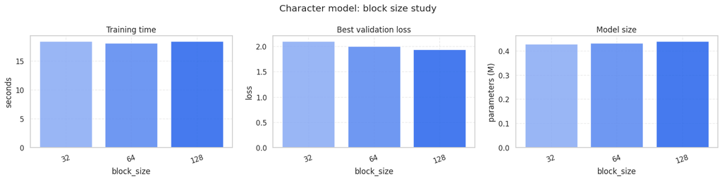

```python
# Load and plot the saved parameter-study summary from CSV.

char_block_summary = load_parameter_summary('pg19_char_block_summary.csv')
plot_parameter_summary(char_block_summary, 'block_size', 'Character model: block size study')
```

### Character Model: Block Size Parameter Study

This experiment tests how changing the `block_size` affects the compact character-level GPT model while keeping the other main settings fixed.

The tested values are:

```
block_size = [32, 64, 128]
```

`block_size` is the context length. It tells the model how many previous tokens it can look at when predicting the next token. Because this is a **character-level** model, a token is one character. So:

- block_size = 32 → the model sees the previous 32 characters
- block_size = 64 → the model sees the previous 64 characters
- block_size = 128 → the model sees the previous 128 characters

A larger block size gives the model more context. This can help it learn longer patterns, such as word endings, punctuation, short phrases, and dialogue structure.

From the results, `block_size = 128` performs best:

| block size | best validation loss |
| --- | --- |
| 128 | 1.937036 |
| 64 | 1.996284 |
| 32 | 2.100789 |

The validation loss decreases as block size increases. This suggests that the character model benefits from seeing a longer context window.

The training-time plot does not increase perfectly linearly, but the differences are small. `block_size = 64` is slightly fastest in this run, while `32` and `128` take a little longer. This can happen because timing is affected by GPU scheduling, memory layout, and runtime noise.

The parameter-count plot increases with `block_size`. This happens because the GPT model has a learned positional embedding table: So when `block_size` increases, the model needs more learned position vectors. The difference is small, but visible:

| block size | parameters |
| --- | --- |
| 32 | 0.427113M |
| 64 | 0.431209M |
| 128 | 0.439401M |

Overall, this study suggests that `block_size = 128` is the best choice among the tested values for the character model. It gives the lowest validation loss, meaning the longer context helps the model make better next-character predictions.

### Impact Of `batch_size`

`batch_size` controls how many independent token blocks are processed in parallel.

|  | batch_size | final_train_loss | final_val_loss | best_val_loss | training_time_s | parameters_m |
| --- | --- | --- | --- | --- | --- | --- |
| 0 | 64 | 1.760495 | 1.932935 | 1.912571 | 19.932248 | 0.431209 |
| 1 | 32 | 1.872125 | 2.013249 | 1.996284 | 18.165425 | 0.431209 |
| 2 | 16 | 1.963310 | 2.139757 | 2.091709 | 17.245523 | 0.431209 |

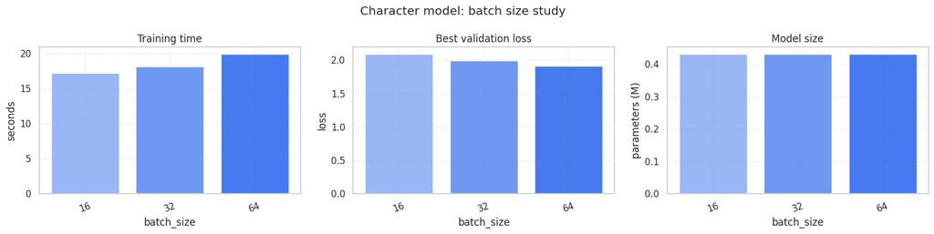

```python
# Load and plot the saved parameter-study summary from CSV.

char_batch_summary = load_parameter_summary('pg19_char_batch_summary.csv')
plot_parameter_summary(char_batch_summary, 'batch_size', 'Character model: batch size study')
```

### Character Model: Batch Size Parameter Study

This experiment tests how changing the `batch_size` affects the compact character-level GPT model while keeping the architecture fixed. The three tested values are:

```
batch_size = [16, 32, 64]
```

A larger batch size means that each training step uses more text sequences at the same time. This usually gives the optimizer a more stable estimate of the gradient, because the update is based on more examples. The tradeoff is that each step takes longer and uses more memory.

From the results, `batch_size = 64` gives the best validation performance:

| batch size | best validation loss |
| --- | --- |
| 64 | 1.912571 |
| 32 | 1.996284 |
| 16 | 2.091709 |

So, in this experiment, increasing the batch size improves the model's ability to generalize to validation data.

The training-time plot shows the expected cost: larger batches take longer. `batch_size = 16` is the fastest, while `batch_size = 64` is the slowest. However, the increase in time is moderate compared with the improvement in validation loss.

The parameter-count plot is flat because `batch_size` does **not** change the model architecture. It only changes how many examples are processed together during training. Therefore, all three runs have the same number of parameters:

- 0.431209 million parameters

Overall, this study suggests that `batch_size = 64` is the best choice among the tested values for the character model, because it achieves the lowest validation loss while keeping the model size unchanged.

### Impact Of `n_layer`

`n_layer` controls how many Transformer blocks are stacked.

|  | n_layer | final_train_loss | final_val_loss | best_val_loss | training_time_s | parameters_m |
| --- | --- | --- | --- | --- | --- | --- |
| 0 | 2 | 1.872125 | 2.013249 | 1.996284 | 18.130341 | 0.431209 |
| 1 | 3 | 1.871157 | 2.012224 | 2.012224 | 25.299400 | 0.629097 |
| 2 | 1 | 1.868042 | 2.061033 | 2.013683 | 11.235936 | 0.233321 |

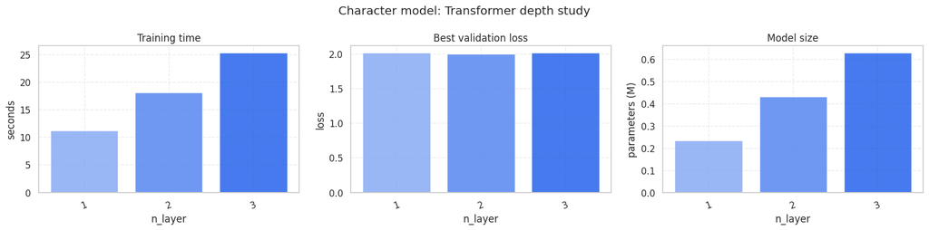

```python
# Load and plot the saved parameter-study summary from CSV.

char_layer_summary = load_parameter_summary('pg19_char_layer_summary.csv')
plot_parameter_summary(char_layer_summary, 'n_layer', 'Character model: Transformer depth study')
```

### Character Model: Number Of Layers Parameter Study

This experiment tests how changing `n_layer` affects the compact character-level GPT model.

The tested values are:

```
n_layer = [1, 2, 3]
```

`n_layer` controls how many Transformer blocks are stacked inside the model. Each layer adds another self-attention block and feed-forward block, so increasing `n_layer` makes the model deeper.

A deeper model can potentially learn more complex patterns, but it also has two costs:

- more parameters
- longer training time

From the results, `n_layer = 2` gives the best validation performance:

| number of layers | best validation loss |
| --- | --- |
| 2 | 1.996284 |
| 3 | 2.012224 |
| 1 | 2.013683 |

The difference between the three models is not very large, but the 2-layer model performs best on validation loss. The 1-layer model is probably too simple, while the 3-layer model adds extra capacity without clearly improving generalization in this compact experiment.

The training-time plot increases as the number of layers increases. This is expected: every extra Transformer layer adds more computation during each forward and backward pass.

The parameter-count plot also increases clearly with `n_layer`:

| number of layers | parameters |
| --- | --- |
| 1 | 0.233321M |
| 2 | 0.431209M |
| 3 | 0.629097M |

This increase is much stronger than in the `block_size` study, because each additional layer adds a full Transformer block, including attention weights, feed-forward weights, layer normalization parameters, and projection matrices.

Overall, this study suggests that `n_layer = 2` is the best choice among the tested values. It gives the lowest validation loss while avoiding the extra training time and parameter cost of the 3-layer model.

### Impact Of `n_head` And `n_embd`

The number of heads controls how many attention views are used. The embedding dimension controls representation size.

|  | n_head | n_embd | final_train_loss | final_val_loss | best_val_loss | training_time_s | parameters_m |
| --- | --- | --- | --- | --- | --- | --- | --- |
| 0 | 4 | 128 | 1.872125 | 2.013249 | 1.996284 | 18.238736 | 0.431209 |
| 1 | 4 | 96 | 1.895052 | 2.056823 | 2.039687 | 18.136239 | 0.249705 |
| 2 | 2 | 64 | 1.999242 | 2.155229 | 2.121104 | 12.621956 | 0.117353 |

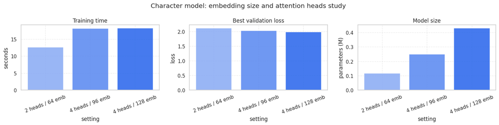

```python
# Load and plot the saved parameter-study summary from CSV.

head_embd_summary = load_parameter_summary('pg19_char_head_embd_summary.csv')
plot_parameter_summary(head_embd_summary, 'embedding / heads', 'Character model: embedding size and attention heads study')
```

### Character Model: Embedding Size And Attention Heads Parameter Study

This experiment compares different combinations of `n_embd` and `n_head` for the compact character-level GPT model.

The tested combinations are:

```
n_head = 2, n_embd = 64
n_head = 4, n_embd = 96
n_head = 4, n_embd = 128
```

`n_embd` controls the size of each token embedding vector. In simple terms, it controls how much internal space the model has to represent each character and its context.

`n_head` controls how many attention heads are used inside each Transformer block. Multiple heads allow the model to attend to different kinds of relationships in the sequence.

The important constraint is that:

```
n_embd % n_head == 0
```

because the embedding dimension must be divisible across the attention heads.

From the results, the largest tested setting performs best:

| n_head | n_embd | best validation loss |
| --- | --- | --- |
| 4 | 128 | 1.996284 |
| 4 | 96 | 2.039687 |
| 2 | 64 | 2.121104 |

So, increasing the embedding size improves validation loss in this experiment. This suggests that the smaller models do not have enough capacity to represent the character-level patterns as well.

The parameter count also increases strongly with `n_embd`:

| n_head | n_embd | parameters |
| --- | --- | --- |
| 2 | 64 | 0.117353M |
| 4 | 96 | 0.249705M |
| 4 | 128 | 0.431209M |

This happens because many parts of the Transformer depend on the embedding size: token embeddings, attention projections, feed-forward layers, layer normalization, and the output head.

Training time is lowest for the smallest model, but the two larger settings take similar time in this run. The best validation result comes from `n_embd = 128` and `n_head = 4`, so this setting gives the best performance among the tested options.

Overall, this study suggests that the character model benefits from a wider representation space, even though it has the largest parameter count

### Impact Of `dropout`

Dropout randomly disables some activations during training and can reduce overfitting.

|  | dropout | final_train_loss | final_val_loss | best_val_loss | training_time_s | parameters_m |
| --- | --- | --- | --- | --- | --- | --- |
| 0 | 0.0 | 1.821937 | 1.964504 | 1.946865 | 17.548151 | 0.431209 |
| 1 | 0.1 | 1.872125 | 2.013249 | 1.996284 | 18.161441 | 0.431209 |
| 2 | 0.2 | 1.924857 | 2.068387 | 2.048178 | 18.344760 | 0.431209 |

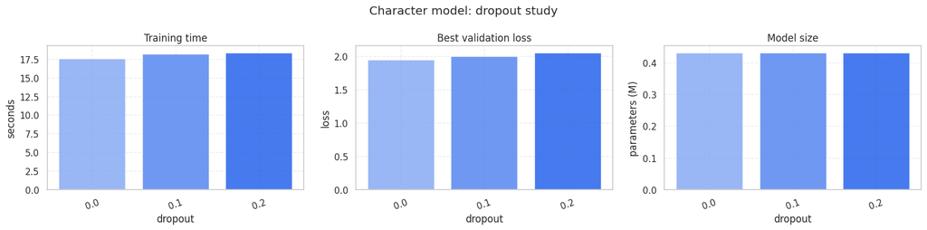

```python
# Load and plot the saved parameter-study summary from CSV.

char_dropout_summary = load_parameter_summary('pg19_char_dropout_summary.csv')
plot_parameter_summary(char_dropout_summary, 'dropout', 'Character model: dropout study')
```

### Character Model: Dropout Parameter Study

This experiment tests how changing `dropout` affects the compact character-level GPT model.

The tested values are:

```
dropout = 0.0, 0.1, 0.2
```

`dropout` is a regularization technique. During training, it randomly turns off part of the model's internal activations. This can help prevent overfitting, because the model cannot rely too heavily on the same internal pathways every time.

A higher dropout value means stronger regularization.

From the results, `dropout = 0.0` performs best:

| dropout | best validation loss |
| --- | --- |
| 0.0 | 1.946865 |
| 0.1 | 1.996284 |
| 0.2 | 2.048178 |

In this compact character-model experiment, adding dropout makes both training loss and validation loss worse. This suggests that the model is not overfitting strongly in this short run. Instead, dropout may be making learning harder by removing useful information during training.

The training-time plot changes only slightly across dropout values. This is expected because dropout changes the training behavior but does not substantially change the number of computations.

The parameter-count plot is flat:

| dropout | parameters |
| --- | --- |
| 0.0 | 0.431209M |
| 0.1 | 0.431209M |
| 0.2 | 0.431209M |

This is because dropout does not add or remove learned weights. It only changes how activations are randomly masked during training.

Overall, this study suggests that `dropout = 0.0` is the best choice among the tested values for the compact character model. The model performs better without dropout, probably because this short experiment benefits more from learning capacity than from extra regularization.

### Learning Rate Analysis

This cell performs a compact learning-rate range test for the character-processing model.

|  | learning_rate | train_loss | val_loss |
| --- | --- | --- | --- |
| 0 | 0.00010 | 4.1396 | 4.1625 |
| 1 | 0.00019 | 3.9953 | 4.0229 |
| 2 | 0.00037 | 3.8011 | 3.8374 |
| 3 | 0.00072 | 3.5022 | 3.5541 |
| 4 | 0.00140 | 3.1891 | 3.2668 |
| 5 | 0.00270 | 3.1072 | 3.2261 |
| 6 | 0.00520 | 3.1397 | 3.2690 |
| 7 | 0.01000 | 3.1837 | 3.3678 |

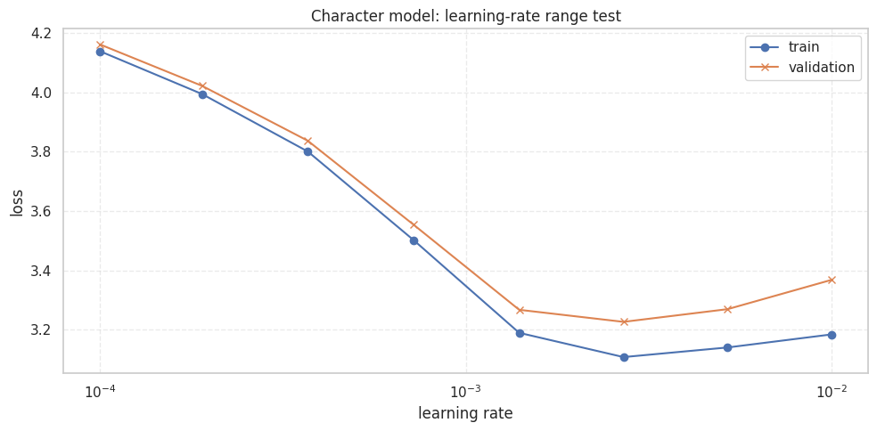

```python
# Recreate the saved learning-rate range test for the character model.

char_lr_summary = plot_learning_rate_summary([
    {'learning_rate': 1.0e-4, 'train_loss': 4.1396, 'val_loss': 4.1625},
    {'learning_rate': 1.9e-4, 'train_loss': 3.9953, 'val_loss': 4.0229},
    {'learning_rate': 3.7e-4, 'train_loss': 3.8011, 'val_loss': 3.8374},
    {'learning_rate': 7.2e-4, 'train_loss': 3.5022, 'val_loss': 3.5541},
    {'learning_rate': 1.4e-3, 'train_loss': 3.1891, 'val_loss': 3.2668},
    {'learning_rate': 2.7e-3, 'train_loss': 3.1072, 'val_loss': 3.2261},
    {'learning_rate': 5.2e-3, 'train_loss': 3.1397, 'val_loss': 3.2690},
    {'learning_rate': 1.0e-2, 'train_loss': 3.1837, 'val_loss': 3.3678},
], 'Character model: learning-rate range test')
```

### Character Model: Learning Rate Range Test

This experiment tests several learning rates for the compact character-level GPT model.

The tested learning rates range from:

$$10^{-4}$$ to $$10^{-2}$$

The learning rate controls how large each optimizer update is during training. If the learning rate is too small, the model learns slowly. If it is too large, training can become unstable or overshoot good solutions.

The validation losses from the test are:

| learning rate | validation loss |
| --- | --- |
| 1.0e-04 | 4.1625 |
| 1.9e-04 | 4.0229 |
| 3.7e-04 | 3.8374 |
| 7.2e-04 | 3.5541 |
| 1.4e-03 | 3.2668 |
| 2.7e-03 | 3.2261 |
| 5.2e-03 | 3.2690 |
| 1.0e-02 | 3.3678 |

The losses decrease as the learning rate increases up to about `2.7e-3`. This means the very small learning rates are too conservative: the model is improving, but not as quickly.

After `2.7e-3`, the validation loss starts increasing again. This suggests that the learning rate is becoming too large. The optimizer is still learning, but its updates may be less stable or may overshoot better parameter values.

This range test identifies `2.7e-3` as the best candidate learning rate among the tested values.

The training loss continues to stay slightly below the validation loss, which is expected. The important pattern is the U-shaped validation curve: validation loss improves as the learning rate becomes more useful, then worsens when the learning rate becomes too aggressive.

### Save Character Parameter Summaries

The character parameter-study results were displayed and also written to `ARTIFACT_DIR` as compact summary tables.

```python
# Save summary tables for the character-model parameter study.

char_parameter_summaries = {
    "block": globals().get("char_block_summary"),
    "batch": globals().get("char_batch_summary"),
    "layer": globals().get("char_layer_summary"),
    "head_embd": globals().get("head_embd_summary"),
    "dropout": globals().get("char_dropout_summary"),
}

for summary_name, summary_df in char_parameter_summaries.items():
    if summary_df is not None:
        out_path = ARTIFACT_DIR / f"pg19_char_{summary_name}_summary.csv"
        summary_df.to_csv(out_path, index=False)
        print(f"Saved {summary_name}: {out_path}")
```

```
Saved block: /content/drive/MyDrive/LM_Project/artifacts/pg19_char_block_summary.csv
Saved batch: /content/drive/MyDrive/LM_Project/artifacts/pg19_char_batch_summary.csv
Saved layer: /content/drive/MyDrive/LM_Project/artifacts/pg19_char_layer_summary.csv
Saved head_embd: /content/drive/MyDrive/LM_Project/artifacts/pg19_char_head_embd_summary.csv
Saved dropout: /content/drive/MyDrive/LM_Project/artifacts/pg19_char_dropout_summary.csv
```

### Syllable Model Parameter Studies

#### Syllable-Processing Parameter Studies

These cells apply the same compact parameter-study idea to the syllable token stream. This matters because one syllable token represents more text than one character token, and the syllable vocabulary is much larger than the character vocabulary. Therefore the best character settings should not be assumed to be best for syllables.

```python
# Define compact settings for the syllable-model parameter studies.

syllable_experiment_settings = {
    "test_block_size": 32,
    "test_batch_size": 16,
    "test_n_embd": 128,
    "test_n_head": 4,
    "test_n_layer": 2,
    "test_dropout": 0.2,
    "test_eval_interval": 25,
    "test_max_iters": 250,
    "learning_rate": 1e-3,
    "num_runs": 2,
}

syllable_experiment_settings
```

```
{'test_block_size': 32,
 'test_batch_size': 16,
 'test_n_embd': 128,
 'test_n_head': 4,
 'test_n_layer': 2,
 'test_dropout': 0.2,
 'test_eval_interval': 25,
 'test_max_iters': 250,
 'learning_rate': 0.001,
 'num_runs': 2}
```

### Syllable Block Size

`block_size` controls how many syllable tokens the model can attend to at once. The values are smaller than the character study because each syllable token covers a larger chunk of language.

|  | block_size | final_train_loss | final_val_loss | best_val_loss | training_time_s | parameters_m |
| --- | --- | --- | --- | --- | --- | --- |
| 0 | 64 | 3.879819 | 4.137182 | 4.137182 | 5.896951 | 6.872143 |
| 1 | 32 | 4.016479 | 4.230842 | 4.230842 | 4.808836 | 6.868047 |
| 2 | 16 | 4.072017 | 4.364016 | 4.350875 | 4.709995 | 6.865999 |

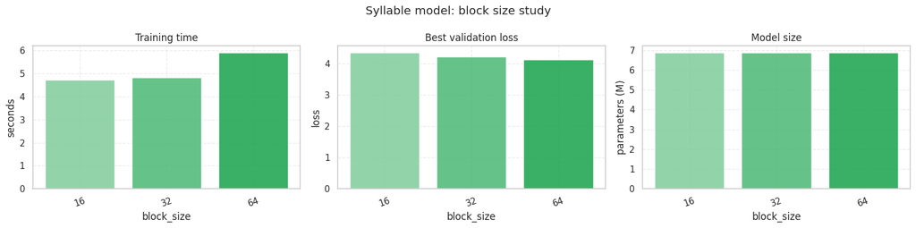

```python
# Load and plot the saved parameter-study summary from CSV.

syllable_block_summary = load_parameter_summary('pg19_syllable_block_summary.csv')
plot_parameter_summary(syllable_block_summary, 'block_size', 'Syllable model: block size study')
```

### Syllable Batch Size

`batch_size` controls how many independent syllable sequences are trained together in one optimizer step.

|  | batch_size | final_train_loss | final_val_loss | best_val_loss | training_time_s | parameters_m |
| --- | --- | --- | --- | --- | --- | --- |
| 0 | 32 | 3.803245 | 4.144187 | 4.067875 | 5.812609 | 6.868047 |
| 1 | 16 | 4.016479 | 4.230842 | 4.230842 | 4.804353 | 6.868047 |
| 2 | 8 | 4.248425 | 4.290828 | 4.290828 | 4.630142 | 6.868047 |

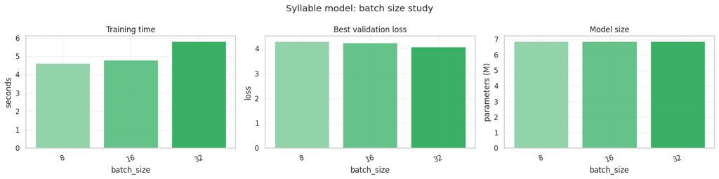

```python
# Load and plot the saved parameter-study summary from CSV.

syllable_batch_summary = load_parameter_summary('pg19_syllable_batch_summary.csv')
plot_parameter_summary(syllable_batch_summary, 'batch_size', 'Syllable model: batch size study')
```

### Syllable Transformer Depth

`n_layer` controls how many Transformer blocks are stacked. More layers can model richer patterns, but they cost more time and can overfit in short compact studies.

|  | n_layer | final_train_loss | final_val_loss | best_val_loss | training_time_s | parameters_m |
| --- | --- | --- | --- | --- | --- | --- |
| 0 | 3 | 3.977313 | 4.131297 | 4.131297 | 6.521494 | 7.065935 |
| 1 | 2 | 4.016479 | 4.230842 | 4.230842 | 4.845853 | 6.868047 |
| 2 | 1 | 4.020042 | 4.261366 | 4.261366 | 3.263312 | 6.670159 |

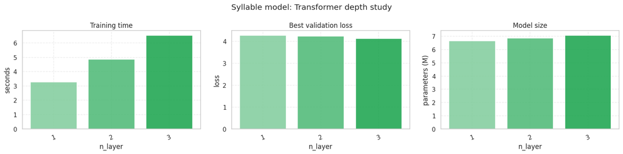

```python
# Load and plot the saved parameter-study summary from CSV.

syllable_layer_summary = load_parameter_summary('pg19_syllable_layer_summary.csv')
plot_parameter_summary(syllable_layer_summary, 'n_layer', 'Syllable model: Transformer depth study')
```

### Syllable Embedding Size And Heads

This compares a few compact attention-width choices. The embedding size must be divisible by the number of heads.

|  | n_head | n_embd | final_train_loss | final_val_loss | best_val_loss | training_time_s | parameters_m |
| --- | --- | --- | --- | --- | --- | --- | --- |
| 0 | 2 | 96 | 3.951843 | 4.220016 | 4.139965 | 3.338797 | 5.083599 |
| 1 | 4 | 128 | 4.016479 | 4.230842 | 4.230842 | 4.818484 | 6.868047 |
| 2 | 4 | 192 | 4.018137 | 4.369262 | 4.279830 | 5.261873 | 10.584399 |

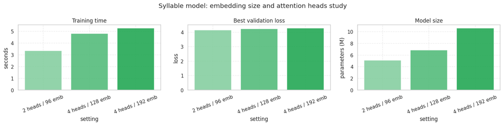

```python
# Load and plot the saved parameter-study summary from CSV.

syllable_head_embd_summary = load_parameter_summary('pg19_syllable_head_embd_summary.csv')
plot_parameter_summary(syllable_head_embd_summary, 'embedding / heads', 'Syllable model: embedding size and attention heads study')
```

### Syllable Dropout

`dropout` randomly hides part of the model activations during training. It can improve generalization, especially with the larger syllable vocabulary.

|  | dropout | final_train_loss | final_val_loss | best_val_loss | training_time_s | parameters_m |
| --- | --- | --- | --- | --- | --- | --- |
| 0 | 0.0 | 3.875223 | 4.103465 | 4.103465 | 4.742850 | 6.868047 |
| 1 | 0.1 | 3.937814 | 4.167408 | 4.167408 | 4.959325 | 6.868047 |
| 2 | 0.2 | 4.016479 | 4.230842 | 4.230842 | 4.878100 | 6.868047 |

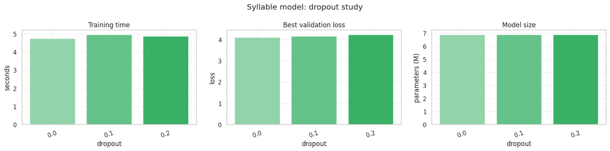

```python
# Load and plot the saved parameter-study summary from CSV.

syllable_dropout_summary = load_parameter_summary('pg19_syllable_dropout_summary.csv')
plot_parameter_summary(syllable_dropout_summary, 'dropout', 'Syllable model: dropout study')
```

### Syllable Learning Rate Analysis

This tests a range of learning rates on a short syllable run. The best value is selected by validation loss.

|  | learning_rate | train_loss | val_loss |
| --- | --- | --- | --- |
| 0 | 0.00010 | 9.4186 | 9.4501 |
| 1 | 0.00019 | 9.1848 | 9.2243 |
| 2 | 0.00037 | 8.9543 | 9.0001 |
| 3 | 0.00072 | 8.5843 | 8.6372 |
| 4 | 0.00140 | 7.8520 | 7.9188 |
| 5 | 0.00270 | 6.4989 | 6.5941 |
| 6 | 0.00520 | 5.2689 | 5.4137 |
| 7 | 0.01000 | 5.8704 | 6.0784 |

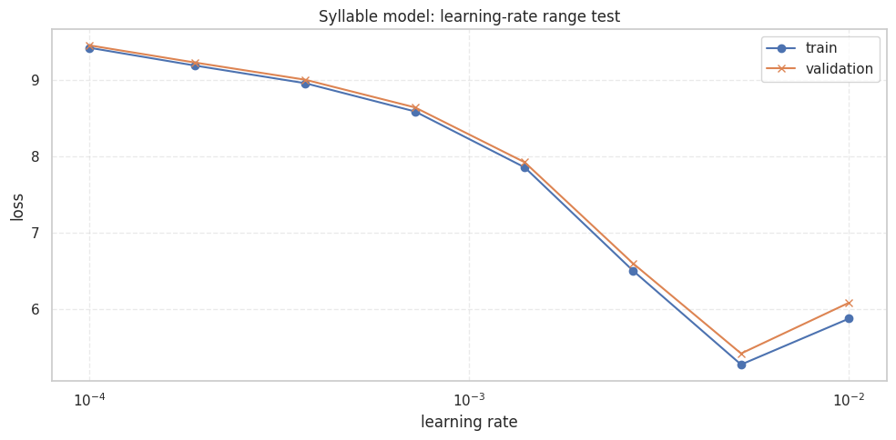

```python
# Recreate the saved learning-rate range test for the syllable model.

syllable_lr_summary = plot_learning_rate_summary([
    {'learning_rate': 1.0e-4, 'train_loss': 9.4186, 'val_loss': 9.4501},
    {'learning_rate': 1.9e-4, 'train_loss': 9.1848, 'val_loss': 9.2243},
    {'learning_rate': 3.7e-4, 'train_loss': 8.9543, 'val_loss': 9.0001},
    {'learning_rate': 7.2e-4, 'train_loss': 8.5843, 'val_loss': 8.6372},
    {'learning_rate': 1.4e-3, 'train_loss': 7.8520, 'val_loss': 7.9188},
    {'learning_rate': 2.7e-3, 'train_loss': 6.4989, 'val_loss': 6.5941},
    {'learning_rate': 5.2e-3, 'train_loss': 5.2689, 'val_loss': 5.4137},
    {'learning_rate': 1.0e-2, 'train_loss': 5.8704, 'val_loss': 6.0784},
], 'Syllable model: learning-rate range test')
```

### Save Syllable Parameter Summaries

The syllable parameter-study results were saved as compact summary CSV files.

```python
# Save summary tables for the syllable-model parameter study.

syllable_parameter_summaries = {
    "block": globals().get("syllable_block_summary"),
    "batch": globals().get("syllable_batch_summary"),
    "layer": globals().get("syllable_layer_summary"),
    "head_embd": globals().get("syllable_head_embd_summary"),
    "dropout": globals().get("syllable_dropout_summary"),
}

for summary_name, summary_df in syllable_parameter_summaries.items():
    if summary_df is not None:
        out_path = ARTIFACT_DIR / f"pg19_syllable_{summary_name}_summary.csv"
        summary_df.to_csv(out_path, index=False)
        print(f"Saved {summary_name}: {out_path}")
```

```
Saved block: /content/drive/MyDrive/LM_Project/artifacts/pg19_syllable_block_summary.csv
Saved batch: /content/drive/MyDrive/LM_Project/artifacts/pg19_syllable_batch_summary.csv
Saved layer: /content/drive/MyDrive/LM_Project/artifacts/pg19_syllable_layer_summary.csv
Saved head_embd: /content/drive/MyDrive/LM_Project/artifacts/pg19_syllable_head_embd_summary.csv
Saved dropout: /content/drive/MyDrive/LM_Project/artifacts/pg19_syllable_dropout_summary.csv
```

### Word/Subword Model Parameter Studies

#### Word/Subword Parameter Studies

These cells apply the same compact parameter-study idea to the word/subword stream. This is the heaviest setting because the vocabulary is much larger than the character and syllable vocabularies. If `tiktoken` is available, this is GPT-2 subword tokenization; otherwise it uses the local word/punctuation fallback defined earlier.

```python
# Define compact settings for the word/subword-model parameter studies.

word_experiment_settings = {
    "test_block_size": 64,
    "test_batch_size": 16,
    "test_n_embd": 128,
    "test_n_head": 4,
    "test_n_layer": 2,
    "test_dropout": 0.2,
    "test_eval_interval": 25,
    "test_max_iters": 250,
    "learning_rate": 3e-4,
    "num_runs": 1,
}

word_experiment_settings
```

```
{'test_block_size': 64,
 'test_batch_size': 16,
 'test_n_embd': 128,
 'test_n_head': 4,
 'test_n_layer': 2,
 'test_dropout': 0.2,
 'test_eval_interval': 25,
 'test_max_iters': 250,
 'learning_rate': 0.0003,
 'num_runs': 1}
```

### Word/Subword Block Size

At word/subword level, a block covers much more semantic context than the same number of character tokens. This study compares compact context windows.

|  | block_size | final_train_loss | final_val_loss | best_val_loss | training_time_s | parameters_m |
| --- | --- | --- | --- | --- | --- | --- |
| 0 | 96 | 6.679305 | 6.928535 | 6.928535 | 13.246980 | 13.324369 |
| 1 | 64 | 6.731299 | 6.950381 | 6.950381 | 9.667199 | 13.320273 |
| 2 | 32 | 6.879738 | 7.130040 | 7.116483 | 6.433788 | 13.316177 |

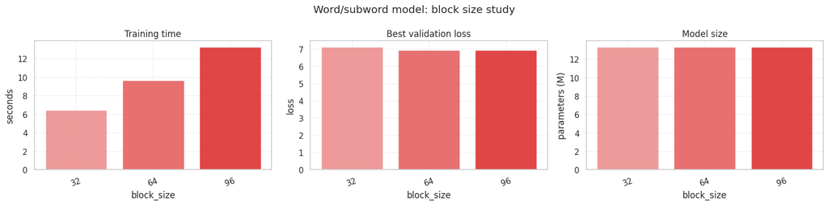

```python
# Load and plot the saved parameter-study summary from CSV.

word_block_summary = load_parameter_summary('pg19_word_block_summary.csv')
plot_parameter_summary(word_block_summary, 'block_size', 'Word/subword model: block size study')
```

### Word/Subword Batch Size

This compares how many word/subword sequences are processed per optimizer step.

|  | batch_size | final_train_loss | final_val_loss | best_val_loss | training_time_s | parameters_m |
| --- | --- | --- | --- | --- | --- | --- |
| 0 | 24 | 6.658209 | 6.964786 | 6.935098 | 13.357235 | 13.320273 |
| 1 | 16 | 6.731299 | 6.950381 | 6.950381 | 9.757235 | 13.320273 |
| 2 | 8 | 6.893504 | 7.123286 | 7.123286 | 6.381422 | 13.320273 |

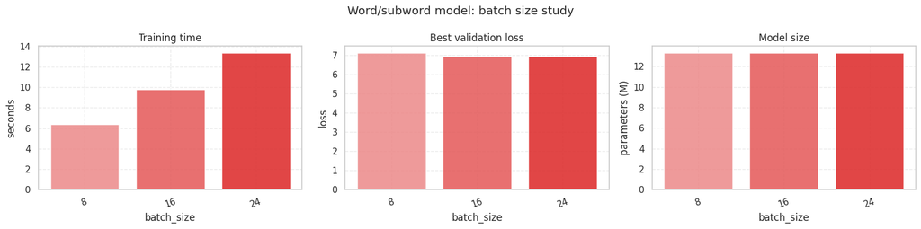

```python
# Load and plot the saved parameter-study summary from CSV.

word_batch_summary = load_parameter_summary('pg19_word_batch_summary.csv')
plot_parameter_summary(word_batch_summary, 'batch_size', 'Word/subword model: batch size study')
```

### Word/Subword Transformer Depth

This tests whether a shallow or moderately deeper model gives better validation loss for the word/subword task.

|  | n_layer | final_train_loss | final_val_loss | best_val_loss | training_time_s | parameters_m |
| --- | --- | --- | --- | --- | --- | --- |
| 0 | 2 | 6.731299 | 6.950381 | 6.950381 | 9.750102 | 13.320273 |
| 1 | 3 | 6.655618 | 7.036482 | 7.030962 | 10.623863 | 13.518161 |
| 2 | 1 | 6.839246 | 7.141601 | 7.141601 | 8.851679 | 13.122385 |

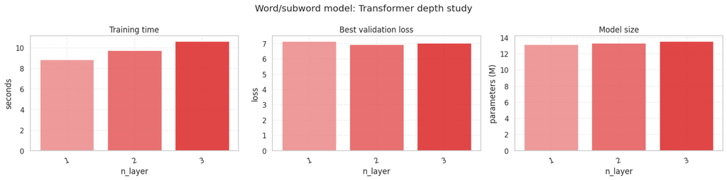

```python
# Load and plot the saved parameter-study summary from CSV.

word_layer_summary = load_parameter_summary('pg19_word_layer_summary.csv')
plot_parameter_summary(word_layer_summary, 'n_layer', 'Word/subword model: Transformer depth study')
```

### Word/Subword Embedding Size And Heads

Because the vocabulary is large, embedding size has a strong effect on parameter count. These values stay compact so the study remains runnable.

|  | n_head | n_embd | final_train_loss | final_val_loss | best_val_loss | training_time_s | parameters_m |
| --- | --- | --- | --- | --- | --- | --- | --- |
| 0 | 4 | 192 | 6.586291 | 6.868618 | 6.868618 | 12.792670 | 20.250193 |
| 1 | 4 | 128 | 6.731299 | 6.950381 | 6.950381 | 9.758231 | 13.320273 |
| 2 | 2 | 96 | 6.943865 | 7.278275 | 7.229421 | 8.456182 | 9.929041 |

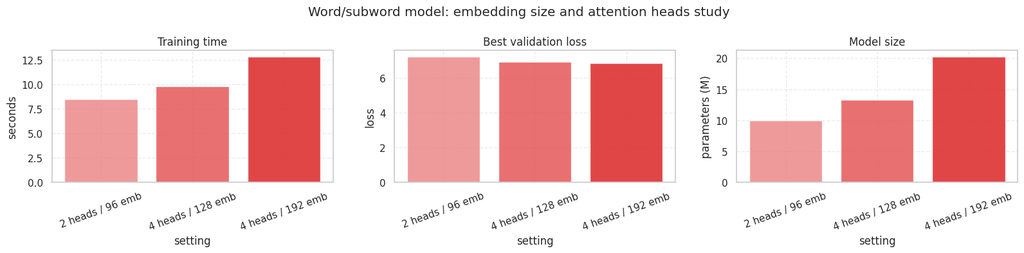

```python
# Load and plot the saved parameter-study summary from CSV.

word_head_embd_summary = load_parameter_summary('pg19_word_head_embd_summary.csv')
plot_parameter_summary(word_head_embd_summary, 'embedding / heads', 'Word/subword model: embedding size and attention heads study')
```

### Word/Subword Dropout

Dropout is especially relevant for the word/subword model because the output space is large and sparse.

|  | dropout | final_train_loss | final_val_loss | best_val_loss | training_time_s | parameters_m |
| --- | --- | --- | --- | --- | --- | --- |
| 0 | 0.0 | 6.609393 | 6.834579 | 6.834579 | 9.648276 | 13.320273 |
| 1 | 0.1 | 6.647221 | 6.870653 | 6.870653 | 9.767748 | 13.320273 |
| 2 | 0.2 | 6.731299 | 6.950381 | 6.950381 | 9.726289 | 13.320273 |

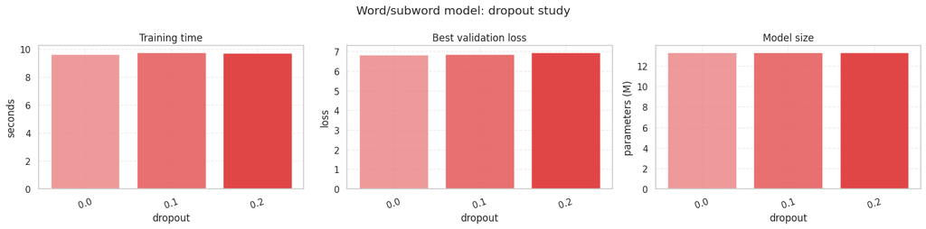

```python
# Load and plot the saved parameter-study summary from CSV.

word_dropout_summary = load_parameter_summary('pg19_word_dropout_summary.csv')
plot_parameter_summary(word_dropout_summary, 'dropout', 'Word/subword model: dropout study')
```

### Word/Subword Learning Rate Analysis

This learning-rate range test uses fewer batches per learning rate because the word/subword model is heavier.

|  | learning_rate | train_loss | val_loss |
| --- | --- | --- | --- |
| 0 | 0.000010 | 10.8416 | 10.8437 |
| 1 | 0.000019 | 10.8232 | 10.8258 |
| 2 | 0.000037 | 10.7884 | 10.7919 |
| 3 | 0.000072 | 10.7270 | 10.7322 |
| 4 | 0.000140 | 10.6366 | 10.6441 |
| 5 | 0.000270 | 10.5286 | 10.5380 |
| 6 | 0.000520 | 10.3848 | 10.3978 |
| 7 | 0.001000 | 10.1314 | 10.1564 |

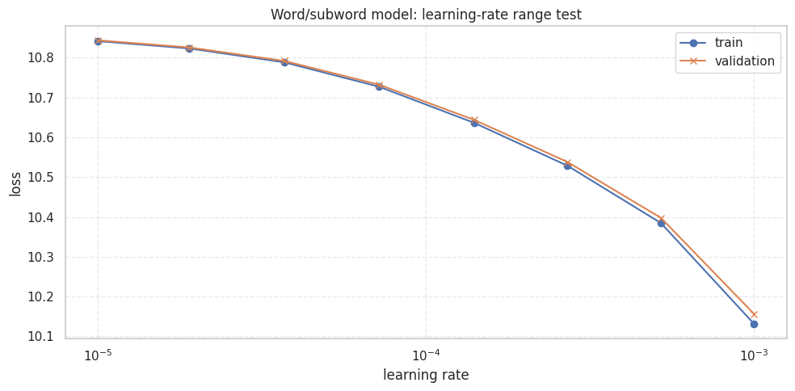

```python
# Recreate the saved learning-rate range test for the word/subword model.

word_lr_summary = plot_learning_rate_summary([
    {'learning_rate': 1.0e-5, 'train_loss': 10.8416, 'val_loss': 10.8437},
    {'learning_rate': 1.9e-5, 'train_loss': 10.8232, 'val_loss': 10.8258},
    {'learning_rate': 3.7e-5, 'train_loss': 10.7884, 'val_loss': 10.7919},
    {'learning_rate': 7.2e-5, 'train_loss': 10.7270, 'val_loss': 10.7322},
    {'learning_rate': 1.4e-4, 'train_loss': 10.6366, 'val_loss': 10.6441},
    {'learning_rate': 2.7e-4, 'train_loss': 10.5286, 'val_loss': 10.5380},
    {'learning_rate': 5.2e-4, 'train_loss': 10.3848, 'val_loss': 10.3978},
    {'learning_rate': 1.0e-3, 'train_loss': 10.1314, 'val_loss': 10.1564},
], 'Word/subword model: learning-rate range test')
```

### Save Word/Subword Parameter Summaries

The word/subword parameter-study results were saved as compact summary CSV files.

```python
# Save summary tables for the word/subword-model parameter study.

word_parameter_summaries = {
    "block": globals().get("word_block_summary"),
    "batch": globals().get("word_batch_summary"),
    "layer": globals().get("word_layer_summary"),
    "head_embd": globals().get("word_head_embd_summary"),
    "dropout": globals().get("word_dropout_summary"),
}

for summary_name, summary_df in word_parameter_summaries.items():
    if summary_df is not None:
        out_path = ARTIFACT_DIR / f"pg19_word_{summary_name}_summary.csv"
        summary_df.to_csv(out_path, index=False)
        print(f"Saved {summary_name}: {out_path}")
```

```
Saved block: /content/drive/MyDrive/LM_Project/artifacts/pg19_word_block_summary.csv
Saved batch: /content/drive/MyDrive/LM_Project/artifacts/pg19_word_batch_summary.csv
Saved layer: /content/drive/MyDrive/LM_Project/artifacts/pg19_word_layer_summary.csv
Saved head_embd: /content/drive/MyDrive/LM_Project/artifacts/pg19_word_head_embd_summary.csv
Saved dropout: /content/drive/MyDrive/LM_Project/artifacts/pg19_word_dropout_summary.csv
```

### Hyperparameter Exploration Summary

The compact studies are used as model-selection evidence rather than as final performance measurements. Final performance is measured only after the longer selected-parameter training runs. The local-word model was kept as an additional compact word-level baseline because it uses a controlled local vocabulary and provides a useful comparison against GPT-2 subword tokenisation.

## 6. Final Selected Hyperparameters

The following cell defines the selected configurations used for the longer final training runs. We trained these models for 100,000 iterations, checked validation every 2,000 iterations, and saved the best validation checkpoint.

### Selected Hyperparameters And Training Budget

### Final Training Utility Functions

These utility functions use the final-training data-tensor interface and are needed to display the selected training plan.

```python
# Define final utilities for splitting data, sampling batches, and estimating loss.

EVAL_ITERS = 10
def split_data(data):
    n=int(0.85*len(data)); return data[:n], data[n:]
def get_batch(data, split, batch_size, block_size):
    tr,va=split_data(data); selected=tr if split=='train' else va; ix=torch.randint(len(selected)-block_size,(batch_size,)); x=torch.stack([selected[i:i+block_size] for i in ix]); y=torch.stack([selected[i+1:i+block_size+1] for i in ix]); return x.to(device), y.to(device)
@torch.no_grad()
def estimate_loss(model,data,batch_size,block_size):
    out={}; model.eval()
    for split in ['train','val']:
        losses=torch.zeros(EVAL_ITERS)
        for k in range(EVAL_ITERS):
            X,Y=get_batch(data,split,batch_size,block_size); _,loss=model(X,Y); losses[k]=loss.item()
        out[split]=losses.mean().item()
    model.train(); return out
def steps_for_fractional_epoch(data,batch_size,block_size,target,min_steps,max_steps):
    train,_=split_data(data); one_epoch=math.ceil(len(train)/(batch_size*block_size)); steps=math.ceil(one_epoch*target); return int(min(max(steps,min_steps),max_steps)), one_epoch
```

```python
# Collect the final selected hyperparameters for the four models.

MODEL_SPECS = {
 'characters': {
     'display_name':'Character GPT',
     'data':data_c,
     'config':{'vocab_size':vocab_size_c,'block_size':128,'n_embed':128,'n_head':4,'n_layer':2,'dropout':0.0},
     'batch_size':64,
     'learning_rate':2.7e-3,
     'max_iters':100000,
     'eval_interval':2000,
 },
 'syllables': {
     'display_name':'Syllable GPT',
     'data':data_s,
     'config':{'vocab_size':vocab_size_s,'block_size':64,'n_embed':96,'n_head':2,'n_layer':3,'dropout':0.0},
     'batch_size':32,
     'learning_rate':5.2e-3,
     'max_iters':100000,
     'eval_interval':2000,
 },
 'word_subwords': {
     'display_name':'GPT-2 Word/Subword GPT',
     'data':data_w,
     'config':{'vocab_size':vocab_size_w,'block_size':96,'n_embed':192,'n_head':4,'n_layer':2,'dropout':0.0},
     'batch_size':24,
     'learning_rate':1.0e-3,
     'max_iters':100000,
     'eval_interval':2000,
 },
 'local_words': {
     'display_name':'Compact Local Word GPT',
     'data':data_lw,
     'config':{'vocab_size':vocab_size_lw,'block_size':128,'n_embed':192,'n_head':6,'n_layer':4,'dropout':0.2},
     'batch_size':16,
     'learning_rate':2.0e-4,
     'max_iters':100000,
     'eval_interval':2000,
 },
}

for name, spec in MODEL_SPECS.items():
    train_data, _ = split_data(spec['data'])
    spec['one_epoch_steps'] = math.ceil(len(train_data) / (spec['batch_size'] * spec['config']['block_size']))
    spec['planned_fractional_epochs'] = spec['max_iters'] / spec['one_epoch_steps']

training_plan_df = pd.DataFrame([
    {
        'model': name,
        **{k:v for k,v in spec['config'].items() if k!='vocab_size'},
        'batch_size': spec['batch_size'],
        'learning_rate': spec['learning_rate'],
        'planned_steps': spec['max_iters'],
        'eval_interval': spec['eval_interval'],
        'one_epoch_steps': spec['one_epoch_steps'],
        'planned_fractional_epochs': spec['planned_fractional_epochs'],
    }
    for name, spec in MODEL_SPECS.items()
])
display(training_plan_df)
```

|  | model | block_size | n_embed | n_head | n_layer | dropout | batch_size | learning_rate | planned_steps | eval_interval | one_epoch_steps | planned_fractional_epochs |
| --- | --- | --- | --- | --- | --- | --- | --- | --- | --- | --- | --- | --- |
| 0 | characters | 128 | 128 | 4 | 2 | 0.0 | 64 | 0.0027 | 100000 | 2000 | 12265 | 8.153282 |
| 1 | syllables | 64 | 96 | 2 | 3 | 0.0 | 32 | 0.0052 | 100000 | 2000 | 24521 | 4.078137 |
| 2 | word_subwords | 96 | 192 | 4 | 2 | 0.0 | 24 | 0.0010 | 100000 | 2000 | 11217 | 8.915040 |
| 3 | local_words | 128 | 192 | 6 | 4 | 0.2 | 16 | 0.0002 | 100000 | 2000 | 11430 | 8.748906 |

## 7. Load Computed Best Models

For the final evaluation we loaded the computed model repository instead of retraining. The repository contains the saved histories, summaries, tokenizers, generated samples, and best-validation checkpoints.

```python
# Load plotting and table utilities, then point them to the extracted model repository.

from pathlib import Path
import json
import shutil
import zipfile
import warnings

import numpy as np
import pandas as pd
import matplotlib.pyplot as plt
from IPython.display import FileLink, display

warnings.filterwarnings('ignore')
plt.style.use('seaborn-v0_8-whitegrid')

ARTIFACT_DIR = MODEL_REPOSITORY_DIR / 'artifacts'
PLOT_DIR = ARTIFACT_DIR / 'diagnostic_plots'
PLOT_DIR.mkdir(parents=True, exist_ok=True)

print('Using repository:', MODEL_REPOSITORY_DIR.resolve())
print('Saving plots to:', PLOT_DIR.resolve())
```

```
Using repository: /content/final_model_repository
Saving plots to: /content/final_model_repository/artifacts/diagnostic_plots
```

```python
# Verify that the computed repository contains explicit best checkpoints.
# These files are used when reloading models for final evaluation.
expected_models = ['characters', 'syllables', 'word_subwords', 'local_words']
BEST_CHECKPOINT_PATHS = {}
missing_best_checkpoints = []

for model_name in expected_models:
    best_path = MODEL_REPOSITORY_DIR / 'checkpoints' / f'{model_name}_best_gpt.pt'
    fallback_path = MODEL_REPOSITORY_DIR / 'checkpoints' / f'{model_name}_gpt.pt'
    if best_path.exists():
        BEST_CHECKPOINT_PATHS[model_name] = best_path
    elif fallback_path.exists():
        # Earlier repository exports saved *_gpt.pt after reloading the best validation state.
        BEST_CHECKPOINT_PATHS[model_name] = fallback_path
    else:
        missing_best_checkpoints.append(model_name)

if missing_best_checkpoints:
    raise FileNotFoundError(f'Missing checkpoint files for: {missing_best_checkpoints}')

for model_name, path in BEST_CHECKPOINT_PATHS.items():
    print(f'{model_name}: {path}')
```

```
characters: /content/final_model_repository/checkpoints/characters_best_gpt.pt
syllables: /content/final_model_repository/checkpoints/syllables_best_gpt.pt
word_subwords: /content/final_model_repository/checkpoints/word_subwords_best_gpt.pt
local_words: /content/final_model_repository/checkpoints/local_words_best_gpt.pt
```

## 8. Final Results

The final results were loaded from the computed repository: summary CSVs, training histories, and generated samples. This kept the final analysis fast after the expensive training had already been completed.

### Load Saved Training Tables

```python
# Load the final summary and history tables from the model repository.

summary_path = ARTIFACT_DIR / 'final_training_summary_all_models.csv'
history_path = ARTIFACT_DIR / 'final_training_history_all_models.csv'

if not summary_path.exists():
    raise FileNotFoundError(summary_path)
if not history_path.exists():
    raise FileNotFoundError(history_path)

final_summary_df = pd.read_csv(summary_path)
final_history_df = pd.read_csv(history_path)

for col in ['iteration', 'encoded_epochs', 'train_loss', 'val_loss', 'val_perplexity', 'learning_rate']:
    if col in final_history_df.columns:
        final_history_df[col] = pd.to_numeric(final_history_df[col], errors='coerce')

final_history_df = final_history_df.sort_values(['model', 'iteration']).reset_index(drop=True)

print('Summary rows:', len(final_summary_df))
print('History rows:', len(final_history_df))
display(final_summary_df.sort_values('best_val_loss'))
display(final_history_df.groupby('model').agg(
    points=('iteration', 'count'),
    first_iteration=('iteration', 'min'),
    last_iteration=('iteration', 'max'),
    min_val_loss=('val_loss', 'min'),
    final_val_loss=('val_loss', 'last'),
    min_val_perplexity=('val_perplexity', 'min'),
))
```

```
Summary rows: 4
History rows: 204
```

|  | model | display_name | block_size | n_embed | n_head | n_layer | dropout | batch_size | learning_rate | planned_steps | best_iteration | best_val_loss | best_val_perplexity | parameters_m | checkpoint_path |
| --- | --- | --- | --- | --- | --- | --- | --- | --- | --- | --- | --- | --- | --- | --- | --- |
| 0 | characters | Character GPT | 128 | 128 | 4 | 2 | 0.0 | 64 | 0.0027 | 100000 | 99999 | 1.442263 | 4.230258 | 0.439401 | /kaggle/working/final_model_repository/checkpo... |
| 1 | syllables | Syllable GPT | 64 | 96 | 2 | 3 | 0.0 | 32 | 0.0052 | 100000 | 92000 | 2.639490 | 14.006060 | 5.198223 | /kaggle/working/final_model_repository/checkpo... |
| 3 | local_words | Compact Local Word GPT | 128 | 192 | 6 | 4 | 0.2 | 16 | 0.0002 | 100000 | 78000 | 4.274332 | 71.832108 | 7.962112 | /kaggle/working/final_model_repository/checkpo... |
| 2 | word_subwords | GPT-2 Word/Subword GPT | 96 | 192 | 4 | 2 | 0.0 | 24 | 0.0010 | 100000 | 42000 | 4.775983 | 118.626907 | 20.256337 | /kaggle/working/final_model_repository/checkpo... |

| model | points | first_iteration | last_iteration | min_val_loss | final_val_loss | min_val_perplexity |
| --- | --- | --- | --- | --- | --- | --- |
| characters | 51 | 0 | 99999 | 1.442263 | 1.442263 | 4.230258 |
| local_words | 51 | 0 | 99999 | 4.274332 | 4.433717 | 71.832108 |
| syllables | 51 | 0 | 99999 | 2.639490 | 2.703932 | 14.006060 |
| word_subwords | 51 | 0 | 99999 | 4.775983 | 5.107876 | 118.626907 |

## 9. Graphs And Comments

These diagnostic plots use the saved training histories. They rescale the original plots so the later training behaviour is visible and add comments directly below each graph.

### Plot Helpers

```python
MODEL_ORDER = ['characters', 'syllables', 'word_subwords', 'local_words']
MODEL_LABELS = {
    'characters': 'Character',
    'syllables': 'Syllable',
    'word_subwords': 'GPT-2 subword',
    'local_words': 'Local word',
}
MODEL_COLORS = {
    'characters': '#2563eb',
    'syllables': '#16a34a',
    'word_subwords': '#dc2626',
    'local_words': '#9333ea',
}

available_models = [model for model in MODEL_ORDER if model in set(final_history_df['model'])]
print('Available models:', available_models)


def model_label(model_name):
    return MODEL_LABELS.get(model_name, model_name)


def finish_plot(fig, filename, dpi=180):
    path = PLOT_DIR / filename
    fig.tight_layout()
    fig.savefig(path, dpi=dpi, bbox_inches='tight')
    print('Saved:', path)
    try:
        link_target = path.relative_to(Path.cwd())
    except ValueError:
        link_target = path
    display(FileLink(link_target))
    plt.show()
    return path


def robust_ylim(values, lower_q=0.02, upper_q=0.98, pad=0.08):
    values = pd.Series(values).replace([np.inf, -np.inf], np.nan).dropna()
    if values.empty:
        return None
    lo = values.quantile(lower_q)
    hi = values.quantile(upper_q)
    if np.isclose(lo, hi):
        lo -= 0.5
        hi += 0.5
    span = hi - lo
    return max(0, lo - span * pad), hi + span * pad
```

```
Available models: ['characters', 'syllables', 'word_subwords', 'local_words']
```

### Graph 1: Loss Overview And Zoom

The top row keeps the full scale. The bottom row removes the initial iteration so the later training behavior is easier to see.

```
Saved: /content/final_model_repository/artifacts/diagnostic_plots/loss_overview_and_zoom.png
```

final_model_repository/artifacts/diagnostic_plots/loss_overview_and_zoom.png

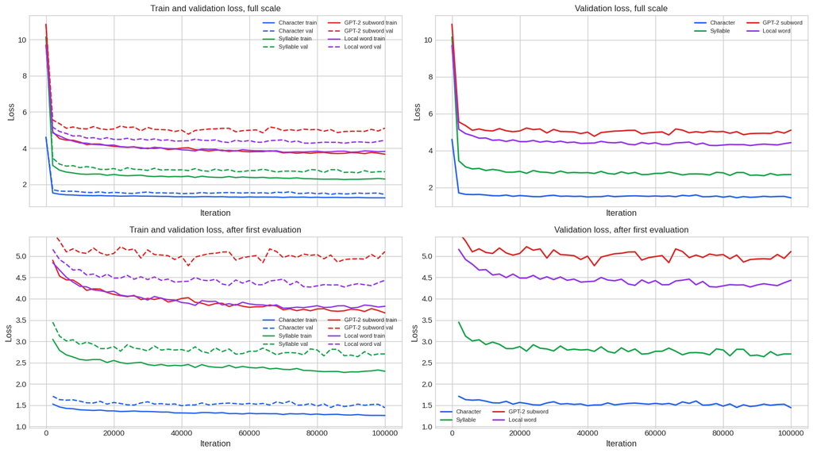

```
PosixPath('/content/final_model_repository/artifacts/diagnostic_plots/loss_overview_and_zoom.png')
```

```python
# Plot the full and zoomed loss curves to compare the models.

fig, axes = plt.subplots(2, 2, figsize=(16, 9), sharex='col')

for model_name in available_models:
    g = final_history_df[final_history_df['model'] == model_name]
    color = MODEL_COLORS.get(model_name)
    label = model_label(model_name)
    axes[0, 0].plot(g['iteration'], g['train_loss'], color=color, linewidth=1.8, label=f'{label} train')
    axes[0, 0].plot(g['iteration'], g['val_loss'], color=color, linewidth=1.8, linestyle='--', label=f'{label} val')
    axes[0, 1].plot(g['iteration'], g['val_loss'], color=color, linewidth=2.0, label=label)

    gz = g[g['iteration'] > g['iteration'].min()]
    axes[1, 0].plot(gz['iteration'], gz['train_loss'], color=color, linewidth=1.8, label=f'{label} train')
    axes[1, 0].plot(gz['iteration'], gz['val_loss'], color=color, linewidth=1.8, linestyle='--', label=f'{label} val')
    axes[1, 1].plot(gz['iteration'], gz['val_loss'], color=color, linewidth=2.0, label=label)

axes[0, 0].set_title('Train and validation loss, full scale')
axes[0, 1].set_title('Validation loss, full scale')
axes[1, 0].set_title('Train and validation loss, after first evaluation')
axes[1, 1].set_title('Validation loss, after first evaluation')

for ax in axes.flat:
    ax.set_xlabel('Iteration')
    ax.set_ylabel('Loss')
    ax.legend(fontsize=8, ncol=2)

zoom_values = []
for model_name in available_models:
    gz = final_history_df[(final_history_df['model'] == model_name) & (final_history_df['iteration'] > final_history_df[final_history_df['model'] == model_name]['iteration'].min())]
    zoom_values.extend(gz['train_loss'].tolist())
    zoom_values.extend(gz['val_loss'].tolist())
ylim = robust_ylim(zoom_values)
if ylim:
    axes[1, 0].set_ylim(*ylim)
    axes[1, 1].set_ylim(*ylim)

finish_plot(fig, 'loss_overview_and_zoom.png')
```

### Comment On Graph 1

This plot shows that all models learn most rapidly in the first few thousand iterations, then improve more gradually. The character model has the lowest numerical loss, but this is expected because it predicts from a very small vocabulary. The syllable model sits in the middle and remains comparatively stable. The GPT-2 subword and local-word models have higher losses because they predict from much larger vocabularies, so their loss values should not be compared directly with character loss as if they were on the same difficulty scale. The zoomed lower panels are the most useful part: they show that training continues to improve after the initial sharp drop, especially for the word-level variants.

### Graph 2: Validation Perplexity With Better Scales

The left plot uses a log scale. The right plot removes the first evaluation point, which is usually the one that crushes everything else.

```
Saved: /content/final_model_repository/artifacts/diagnostic_plots/validation_perplexity_rescaled.png
```

final_model_repository/artifacts/diagnostic_plots/validation_perplexity_rescaled.png

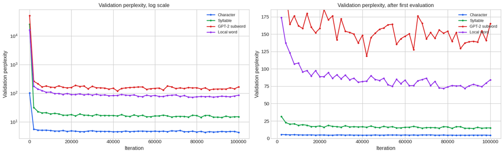

```
PosixPath('/content/final_model_repository/artifacts/diagnostic_plots/validation_perplexity_rescaled.png')
```

```python
# Plot validation perplexity using more readable scales.

fig, axes = plt.subplots(1, 2, figsize=(16, 5))

for model_name in available_models:
    g = final_history_df[final_history_df['model'] == model_name]
    color = MODEL_COLORS.get(model_name)
    label = model_label(model_name)
    axes[0].plot(g['iteration'], g['val_perplexity'], marker='o', markersize=3, linewidth=1.8, color=color, label=label)
    gz = g[g['iteration'] > g['iteration'].min()]
    axes[1].plot(gz['iteration'], gz['val_perplexity'], marker='o', markersize=3, linewidth=1.8, color=color, label=label)

axes[0].set_yscale('log')
axes[0].set_title('Validation perplexity, log scale')
axes[1].set_title('Validation perplexity, after first evaluation')

zoom_ppl = []
for model_name in available_models:
    g = final_history_df[final_history_df['model'] == model_name]
    zoom_ppl.extend(g[g['iteration'] > g['iteration'].min()]['val_perplexity'].tolist())
ylim = robust_ylim(zoom_ppl, lower_q=0.01, upper_q=0.95, pad=0.12)
if ylim:
    axes[1].set_ylim(*ylim)

for ax in axes:
    ax.set_xlabel('Iteration')
    ax.set_ylabel('Validation perplexity')
    ax.legend(fontsize=9)

finish_plot(fig, 'validation_perplexity_rescaled.png')
```

### Comment On Graph 2

The log-scale perplexity plot fixes the main problem in the original graph: the first evaluation point was so large that it compressed all later points. After the first evaluation, the character model has the lowest perplexity, followed by the syllable model, then the local-word model, with GPT-2 subwords highest. This ordering is partly influenced by vocabulary size, so perplexity should be interpreted within each tokenizer rather than as a perfectly fair cross-tokenizer ranking. The important trend is that perplexity drops strongly early and then stabilizes, which suggests the models are learning useful structure from the corpus.

### Graph 3: One Panel Per Model

This avoids comparing tokenizations on one crowded axis. Each model gets its own loss and perplexity view.

```
Saved: /content/final_model_repository/artifacts/diagnostic_plots/per_model_training_diagnostics.png
```

final_model_repository/artifacts/diagnostic_plots/per_model_training_diagnostics.png

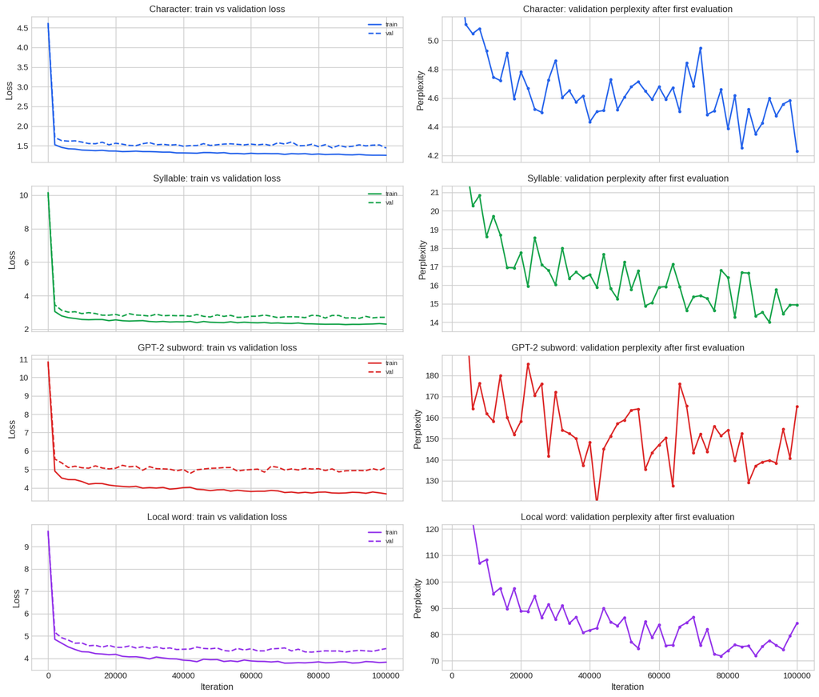

```
PosixPath('/content/final_model_repository/artifacts/diagnostic_plots/per_model_training_diagnostics.png')
```

```python
# Plot separate diagnostics for each model so each curve has its own scale.

fig, axes = plt.subplots(len(available_models), 2, figsize=(15, 3.2 * len(available_models)), sharex='col')
if len(available_models) == 1:
    axes = np.array([axes])

for row, model_name in enumerate(available_models):
    g = final_history_df[final_history_df['model'] == model_name]
    gz = g[g['iteration'] > g['iteration'].min()]
    color = MODEL_COLORS.get(model_name)
    label = model_label(model_name)

    axes[row, 0].plot(g['iteration'], g['train_loss'], color=color, linewidth=1.8, label='train')
    axes[row, 0].plot(g['iteration'], g['val_loss'], color=color, linewidth=1.8, linestyle='--', label='val')
    axes[row, 0].set_title(f'{label}: train vs validation loss')
    axes[row, 0].set_ylabel('Loss')
    axes[row, 0].legend(fontsize=8)

    axes[row, 1].plot(gz['iteration'], gz['val_perplexity'], color=color, linewidth=1.8, marker='o', markersize=3)
    axes[row, 1].set_title(f'{label}: validation perplexity after first evaluation')
    axes[row, 1].set_ylabel('Perplexity')

    ylim = robust_ylim(gz['val_perplexity'], lower_q=0.02, upper_q=0.95, pad=0.12)
    if ylim:
        axes[row, 1].set_ylim(*ylim)

for ax in axes[-1, :]:
    ax.set_xlabel('Iteration')

finish_plot(fig, 'per_model_training_diagnostics.png')
```

### Comment On Graph 3

These per-model panels are the clearest diagnostic view because each tokenizer gets its own scale. The character model converges smoothly and keeps a small gap between train and validation loss. The syllable model also improves steadily and gives a stronger linguistic unit than raw characters. The GPT-2 subword model learns, but its validation curve is noisier and remains separated from the training curve, suggesting the task is harder and/or the model may need more data or regularization. The local-word model improves substantially and has lower perplexity than GPT-2 subwords here, but it still shows a visible train-validation gap.

### Graph 4: Best Validation Metrics

Perplexity is shown on a log scale because the tokenizations have very different vocabulary sizes and perplexity ranges.

```
Saved: /content/final_model_repository/artifacts/diagnostic_plots/best_validation_metrics.png
```

final_model_repository/artifacts/diagnostic_plots/best_validation_metrics.png

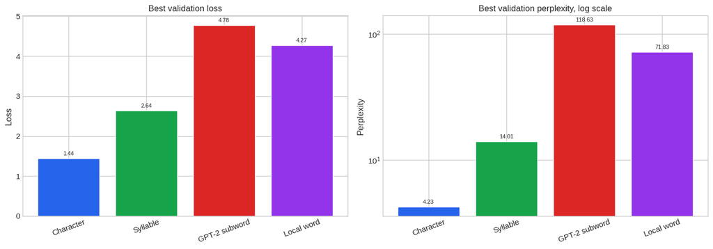

```
PosixPath('/content/final_model_repository/artifacts/diagnostic_plots/best_validation_metrics.png')
```

```python
plot_summary = final_summary_df.copy()
plot_summary['label'] = plot_summary['model'].map(MODEL_LABELS).fillna(plot_summary['model'])
plot_summary['color'] = plot_summary['model'].map(MODEL_COLORS).fillna('#64748b')
plot_summary = plot_summary.set_index('model').loc[available_models].reset_index()

fig, axes = plt.subplots(1, 2, figsize=(14, 5))
axes[0].bar(plot_summary['label'], plot_summary['best_val_loss'], color=plot_summary['color'])
axes[0].set_title('Best validation loss')
axes[0].set_ylabel('Loss')
axes[0].tick_params(axis='x', rotation=20)

axes[1].bar(plot_summary['label'], plot_summary['best_val_perplexity'], color=plot_summary['color'])
axes[1].set_yscale('log')
axes[1].set_title('Best validation perplexity, log scale')
axes[1].set_ylabel('Perplexity')
axes[1].tick_params(axis='x', rotation=20)

for ax in axes:
    for container in ax.containers:
        ax.bar_label(container, fmt='%.2f', fontsize=8, padding=3)

finish_plot(fig, 'best_validation_metrics.png')
```

### Comment On Graph 4

This summary compares the best validation point reached by each model. The character model has the best numerical loss and perplexity, but it also has the smallest prediction vocabulary, so it is not automatically the best text generator. The syllable model is a strong compromise: it has much better metrics than the word-level models while using more meaningful units than characters. Between the two word-based approaches, the compact local-word model performs better according to best validation loss and perplexity, but this numerical result should be read together with the generated samples because the local-word tokenizer can replace many rare words with `[UNK]`.

### Graph 5: Generalization Gap

This shows `validation loss - train loss`. Smaller gaps usually mean less overfitting, but the values should be interpreted separately for each tokenizer.

```
Saved: /content/final_model_repository/artifacts/diagnostic_plots/generalization_gap.png
```

final_model_repository/artifacts/diagnostic_plots/generalization_gap.png

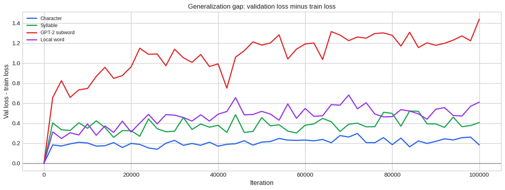

```
PosixPath('/content/final_model_repository/artifacts/diagnostic_plots/generalization_gap.png')
```

```python
gap_df = final_history_df.copy()
gap_df['generalization_gap'] = gap_df['val_loss'] - gap_df['train_loss']

fig, ax = plt.subplots(figsize=(13, 5))
for model_name in available_models:
    g = gap_df[gap_df['model'] == model_name]
    ax.plot(
        g['iteration'],
        g['generalization_gap'],
        color=MODEL_COLORS.get(model_name),
        linewidth=2,
        label=model_label(model_name),
    )

ax.axhline(0, color='#111827', linewidth=1, alpha=0.5)
ax.set_title('Generalization gap: validation loss minus train loss')
ax.set_xlabel('Iteration')
ax.set_ylabel('Val loss - train loss')
ax.legend(fontsize=9)
finish_plot(fig, 'generalization_gap.png')
```

### Comment On Graph 5

The generalization gap measures validation loss minus training loss. A small gap means the model behaves similarly on train and validation data; a large or growing gap suggests overfitting. The character model has the smallest and most stable gap. The syllable and local-word models show moderate gaps, which is acceptable but worth monitoring. The GPT-2 subword model has the largest gap, meaning it fits the training data more strongly than the validation data; this is the clearest sign that the subword model is the most difficult to generalize in this experiment.

## 10. Generated Samples

The samples below are loaded from the computed model repository. They are generated outputs from the final trained models, not new training runs.

```python
# Load the generated texts saved during final evaluation.

samples_path = MODEL_REPOSITORY_DIR / 'samples' / 'final_model_generations.csv'
if not samples_path.exists():
    raise FileNotFoundError(samples_path)

generation_df = pd.read_csv(samples_path)
print('Generated samples:', len(generation_df))
display(generation_df)
```

```
Generated samples: 12
```

|  | model | prompt | generated_text |
| --- | --- | --- | --- |
| 0 | characters | The old house stood at the end of the lane. | The old house stood at the end of the lane.\n\... |
| 1 | characters | In the library, Clara found a letter. | In the library, Clara found a letter.\n\n"It's... |
| 2 | characters | The road was white with winter dust. | The road was white with winter dust.\n\nStill ... |
| 3 | syllables | The old house stood at the end of the lane. | The old house stood at the end of the lane.\n\... |
| 4 | syllables | In the library, Clara found a letter. | In the library, clara found a letter.\n\n"i ha... |
| 5 | syllables | The road was white with winter dust. | The road was white with winter dust.\n\n"well,... |
| 6 | word_subwords | The old house stood at the end of the lane. | The old house stood at the end of the lane.\n\... |
| 7 | word_subwords | In the library, Clara found a letter. | In the library, Clara found a letter.\n\n\nCha... |
| 8 | word_subwords | The road was white with winter dust. | The road was white with winter dust.\n\n\nCHAP... |
| 9 | local_words | The old house stood at the end of the lane. | the old house stood at the end of the lane.\n"... |
| 10 | local_words | In the library, Clara found a letter. | in the library, clara found a letter.\n" i am ... |
| 11 | local_words | The road was white with winter dust. | the road was white with winter dust.\n" well, ... |

### Generate Fresh Samples From The Best Checkpoints

We also reload the best saved checkpoint for each model and generate a short fresh continuation from the same prompt. This verifies that the repository contains usable model weights, not only precomputed CSV outputs.

```python
# Reload the best checkpoints and generate fresh samples from the same prompt.

GENERATION_PROMPT = 'The '
GENERATION_TEMPERATURE = 0.9
GENERATION_TOP_K = 50
GENERATION_TOKENS = {
    'characters': 1200,
    'syllables': 1000,
    'word_subwords': 500,
    'local_words': 500,
}

pd.set_option('display.max_colwidth', None)
pd.set_option('display.width', 180)


def encode_word_subwords(text_value):
    if USE_TIKTOKEN:
        return enc.encode(str(text_value))
    return encode_words(text_value)


def decode_word_subwords(ids):
    if USE_TIKTOKEN:
        return enc.decode([int(i) for i in ids])
    return decode_words(ids)


GENERATION_ENCODERS = {
    'characters': encode_chars,
    'syllables': encode_syllables,
    'word_subwords': encode_word_subwords,
    'local_words': encode_local_words,
}

GENERATION_DECODERS = {
    'characters': decode_chars,
    'syllables': decode_syllables,
    'word_subwords': decode_word_subwords,
    'local_words': decode_local_words,
}


def load_best_checkpoint_model(model_name):
    checkpoint = torch.load(
        BEST_CHECKPOINT_PATHS[model_name],
        map_location=device,
        weights_only=False,  # trusted checkpoint created by this project
    )
    config = dict(checkpoint.get('config', MODEL_SPECS[model_name]['config']))
    model = GPTLanguageModel(**config).to(device)
    model.load_state_dict(checkpoint['model_state_dict'])
    model.eval()
    return model


fresh_rows = []
for model_name in available_models:
    encoder = GENERATION_ENCODERS[model_name]
    decoder = GENERATION_DECODERS[model_name]
    prompt_ids = encoder(GENERATION_PROMPT)
    if len(prompt_ids) == 0:
        prompt_ids = [0]

    model = load_best_checkpoint_model(model_name)
    context = torch.tensor([prompt_ids], dtype=torch.long, device=device)
    with torch.no_grad():
        generated_ids = model.generate(
            context,
            max_new_tokens=GENERATION_TOKENS[model_name],
            temperature=GENERATION_TEMPERATURE,
            top_k=GENERATION_TOP_K,
        )[0].tolist()

    fresh_rows.append({
        'model': model_label(model_name),
        'prompt': GENERATION_PROMPT,
        'generated_text': decoder(generated_ids),
    })

fresh_generation_df = pd.DataFrame(fresh_rows)
display(fresh_generation_df)
```

|  | model | prompt | generated_text |
| --- | --- | --- | --- |
| 0 | Character | The | The Friends. The Philipfellation\nwas if she had taken for Forth was not so an objection between this woman\nnamed Mr. Virginian reputations, none of the people. On the time of\nLeo, it was struck fro… |
| 1 | Syllable | The | The event of a general forces. The\nrepublic was also much-known, and the same elector in case the nation of\nthe increases of the advantages, and the advanced abundance on the\nmountains, a latent ex… |
| 2 | GPT-2 subword | The | The izard, Rufus,\nKlour,\nWhom, as I have seen,\n And hadst the world\n By the _Tall_ his "Thou doleful."\n\nAnd now the King came from the town, and the King went along.\n\nThey both were like men, … |
| 3 | Local word | The | the [UNK] of [UNK], the\n[UNK] [UNK], and the [UNK], the [UNK] and the [UNK]\n[UNK] of one or other [UNK], and its [UNK] to a [UNK]; they\nhave not heard of it, or of their [UNK].\nthe first place in … |

### Comment On Generated Samples

The generated samples show a difference that is not fully captured by validation loss. The character and syllable models often produce plausible word-like or sentence-like text, even when the meaning is unstable. The GPT-2 subword model can produce more natural-looking phrases, but it is also noisier and sometimes drifts into strange names or formatting.

The local-word model has a clear `[UNK]` problem. Because its vocabulary was capped, many rare words, names, references, and formatting tokens are mapped to `[UNK]`. This helps keep the model smaller and easier to train, but it makes the generated text less readable when too many unknown tokens appear. The GPT-2 subword model does not have this exact problem, because rare words can usually be split into smaller subword pieces instead of being replaced by a single unknown token. For this reason, the local-word model is not simply better than GPT-2/tiktoken: it is better on our saved validation metrics, while GPT-2/tiktoken is more robust for open-vocabulary generation.

## 11. Final Discussion

The character model achieved the best numerical validation loss and perplexity, but this was partly because it predicted from a very small vocabulary. It was the most stable model and had the smallest generalisation gap.

The syllable model was a strong compromise. It used more linguistically meaningful units than characters while keeping validation metrics much better than the word-level models.

The GPT-2 word/subword model was the largest and hardest to generalise in this experiment. Its generalisation gap was the highest, suggesting that this architecture and dataset size were not enough to make the subword model outperform the simpler alternatives.

The compact local-word model achieved better validation loss and perplexity than the GPT-2 subword model in this specific setup. However, after looking at the generated samples, we should not conclude that the local-word tokenizer is generally better than GPT-2/tiktoken. Its controlled vocabulary made it easier to train and gave strong numerical results, but it also produced many `[UNK]` tokens. This happens because rare words are removed from the fixed vocabulary and replaced with one unknown-token symbol. As a result, the model can learn sentence structure, but readability suffers when the continuation needs names, uncommon words, or bibliographic/illustration-like material. GPT-2/tiktoken had weaker metrics here, but it is more robust for open-vocabulary text because it can represent rare words as subword pieces instead of collapsing them into `[UNK]`.

Overall, the final selected models were evaluated using the saved best-validation checkpoints in `final_model_repository/checkpoints`, especially the explicit `*_best_gpt.pt` files.

A natural next step would be to improve the local-word tokenizer so it keeps the practical advantages of a controlled vocabulary without producing so many `[UNK]` tokens. We could increase the vocabulary size, use a minimum-frequency threshold more carefully, add a better fallback for rare words, or move to a subword tokenizer trained directly on this corpus. This would probably make the local-word generations more readable while keeping the model smaller than a full word-level system.

```python
# save notebook as HTML

import json
from pathlib import Path
import zipfile
from google.colab import drive

# Mount Google Drive to access the project repository
drive.mount('/content/drive')

# 1. Define file paths for the source notebook and the temporary clean version
input_path = Path("/content/drive/MyDrive/LM_Project/LM_Project_GPTLanguageModel.ipynb")
clean_path = Path("/content/LM_Project_HTML.ipynb")

# 2. Load the notebook JSON data to strip out corrupt widget metadata
# (e.g., custom tqdm or interactive UI states that break standard nbconvert)
with open(input_path, 'r', encoding='utf-8') as f:
    nb_data = json.load(f)

# Remove global widget data from the notebook's top-level metadata
if "widgets" in nb_data.get("metadata", {}):
    del nb_data["metadata"]["widgets"]

# Iterate through all cells to remove localized widget states from execution outputs
for cell in nb_data.get("cells", []):
    if "outputs" in cell:
        for output in cell["outputs"]:
            if "metadata" in output and "widgets" in output["metadata"]:
                del output["metadata"]["widgets"]

# 3. Save the sanitized notebook instance to the local Colab runtime environment
with open(clean_path, 'w', encoding='utf-8') as f:
    json.dump(nb_data, f, indent=1)

# 4. Compile the clean notebook into a production-ready HTML document for evaluation
!jupyter nbconvert --to html {clean_path}
```

```
[NbConvertApp] Converting notebook /content/LM_Project_HTML.ipynb to html
[NbConvertApp] WARNING | Alternative text is missing on 24 image(s).
[NbConvertApp] Writing 3153358 bytes to /content/LM_Project_HTML.html
```